# CHF Safe-Haven Effect - Macroeconometrics Project

## 9.4 VAR Stability - Companion Roots

All eigenvalues of the companion matrix must lie strictly inside the unit circle for the VAR to be stable and the impulse responses to be meaningful. The plot below confirms this condition holds for both models A and B.

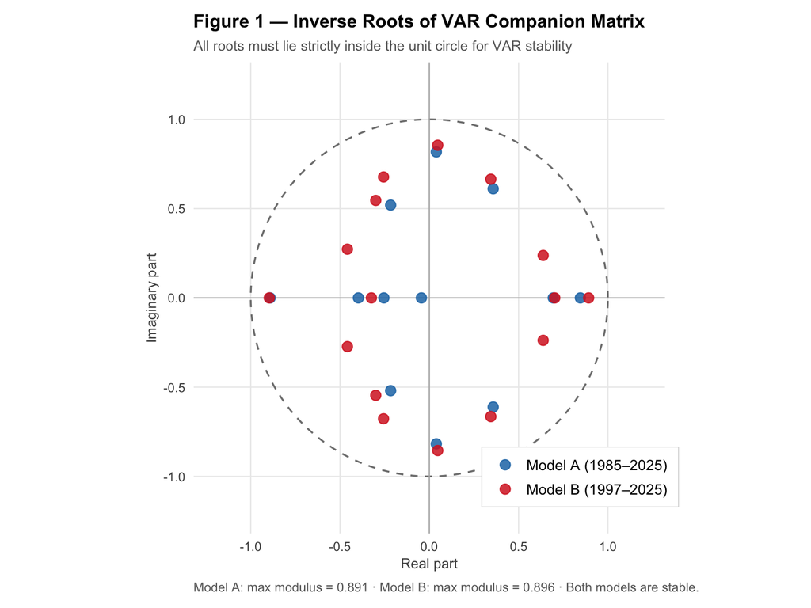

```r
# Extract companion matrix roots for both models
roots_df <- bind_rows(
  tibble(
    model  = "Model A (1985–2025)",
    root   = roots(var_A, modulus = FALSE)
  ),
  tibble(
    model  = "Model B (1997–2025)",
    root   = roots(var_B, modulus = FALSE)
  )
) %>%
  mutate(
    real    = Re(root),
    imag    = Im(root),
    modulus = Mod(root)
  )

# Unit circle points
unit_circle <- tibble(
  angle = seq(0, 2 * pi, length.out = 300),
  x     = cos(angle),
  y     = sin(angle)
)

ggplot() +
  # Unit circle
  geom_path(data = unit_circle,
            aes(x = x, y = y),
            color = "grey50", linewidth = 0.6, linetype = "dashed") +
  # Axes
  geom_hline(yintercept = 0, color = "grey70", linewidth = 0.4) +
  geom_vline(xintercept = 0, color = "grey70", linewidth = 0.4) +
  # Roots
  geom_point(data = roots_df,
             aes(x = real, y = imag, color = model),
             size = 3, alpha = 0.85) +
  scale_color_manual(
    values = c("Model A (1985–2025)" = "#1f77b4",
               "Model B (1997–2025)" = "#d62728"),
    name   = NULL
  ) +

  coord_fixed(xlim = c(-1.2, 1.2), ylim = c(-1.2, 1.2)) +
  labs(
    title    = "Figure 1 — Inverse Roots of VAR Companion Matrix",
    subtitle = "All roots must lie strictly inside the unit circle for VAR stability",
    caption = paste0("Model A: max modulus = ", round(max(roots(var_A)), 3),
                 " · Model B: max modulus = ", round(max(roots(var_B)), 3),
                 " · Both models are stable."),
    x        = "Real part",
    y        = "Imaginary part"
  ) +
  theme_chf() +
  theme(
    legend.position = c(0.82, 0.12),
    legend.background = element_rect(fill = "white", color = "grey85",
                                     linewidth = 0.3),
    legend.margin   = margin(4, 8, 4, 8),
    plot.caption    = element_text(size = 9, color = "grey40",
                                   hjust = 0, margin = margin(t = 8))
  )
```

Figure 1 plots plots the eigenvalues of the VAR companion matrix in the complex plane to verify model stability. Although VAR coefficients are real-valued, eigenvalues are generally complex numbers $a + bi$, with real and imaginary components on the respective axes. Stability requires that the modulus of each eigenvalue $\sqrt{a^2 + b^2}$, therefore its distance from the origin, is strictly less than one. All eigenvalues lying inside the unit circle confirms this condition is satisfied, guaranteeing that impulse responses decay toward zero and validating the VAR specification. Meaning essentially that the system returns to equilibrium after a shock rather than diverging.

## 9.5 Identification — Cholesky Decomposition

To give the VAR residuals a causal interpretation, we need to transform them from correlated reduced-form residuals retrieved from the VAR estimations into uncorrelated structural shocks. This is done through a Cholesky decomposition of the residual covariance matrix $\boldsymbol{\Sigma} = \mathbf{P}\mathbf{P}'$, where $\mathbf{P}$ is a lower triangular matrix. The lower triangular matrix P below makes this identification assumption explicit.The zero restrictions in the upper triangle of $\mathbf{P}$ encode the identification assumption: variables ordered earlier in the system can affect all subsequent variables within the same quarter, but cannot themselves be affected by variables ordered later. We impose the following ordering for model A:

$$\Delta \ln(\text{GPR}) \rightarrow \text{Yield Spread} \rightarrow \Delta \ln(\text{Portfolio Inflows})$$
And for model B we impose:
$$\Delta \ln(\text{GPR}) \rightarrow \text{Yield Spread} \rightarrow \Delta \text{FX Reserves} \rightarrow \Delta \ln(\text{Portfolio Inflows})$$
Those orderings reflect the economic logic of the safe-haven channel. Geopolitical risk is driven by global political events that are independent of Swiss financial market conditions. GPR can therefore affect both the yield spread and portfolio inflows contemporaneously but is not itself affected by either within the same quarter. The yield spread reflects monetary policy dynamics that respond to geopolitical conditions but move independently of short-run capital flows. Portfolio inflows are the most endogenous variable within the model and they absorb the effects of both GPR and yield spread (Model A) and additionally the FX reserves (Model B) shocks within the quarter, but do not feed back into either until the following quarter. The diagonal elements within the tables confirm the structural shock standard deviations used to scale the IRFs in Section 10.

```r
# Model A Cholesky Decomposition
# Residual covariance matrix from VAR estimation
residual_cov_A <- summary(var_A)$covres

# Lower triangular Cholesky factor P such that Sigma = P * P'
# Diagonal of P = structural shock standard deviations
# Off-diagonal lower elements = permitted contemporaneous transmission
cholesky_lower_A <- t(chol(residual_cov_A))

# Model B Cholesky Decomposition
residual_cov_B <- summary(var_B)$covres
cholesky_lower_B <- t(chol(residual_cov_B))

# Model A:
tibble(
  Variable = c("Δ ln(GPR)", "Yield Spread", "Δ ln(Portfolio Inflows)"),
  GPR      = round(cholesky_lower_A[, 1], 4),
  Spread   = round(cholesky_lower_A[, 2], 4),
  Inflows  = round(cholesky_lower_A[, 3], 4)
) %>%
  gt() %>%
  tab_header(
    title    = md("**Cholesky Decomposition — Model A (1985–2025)**"),
    subtitle = md("*Lower triangular matrix P · Cholesky identification · diagonal = structural shock SD*")
  ) %>%
  tab_spanner(
    label   = "Structural Shock",
    columns = c(GPR, Spread, Inflows)
  ) %>%
  cols_label(
    Variable = " ",
    GPR      = "Δ ln(GPR)",
    Spread   = "Yield Spread",
    Inflows  = "Δ ln(Inflows)"
  ) %>%
  cols_align(align = "left",   columns = Variable) %>%
  cols_align(align = "center", columns = c(GPR, Spread, Inflows)) %>%
  cols_width(
    Variable ~ px(200),
    GPR      ~ px(110),
    Spread   ~ px(110),
    Inflows  ~ px(110)
  ) %>%
  # Highlight diagonal
  tab_style(
    style     = list(cell_fill(color = "#f5f5f5"),
                     cell_text(weight = "bold")),
    locations = cells_body(rows = 1, columns = GPR)
  ) %>%
  tab_style(
    style     = list(cell_fill(color = "#f5f5f5"),
                     cell_text(weight = "bold")),
    locations = cells_body(rows = 2, columns = Spread)
  ) %>%
  tab_style(
    style     = list(cell_fill(color = "#f5f5f5"),
                     cell_text(weight = "bold")),
    locations = cells_body(rows = 3, columns = Inflows)
  ) %>%
  # Zero upper triangle — grey italic
  tab_style(
    style     = cell_text(color = "grey70", style = "italic"),
    locations = cells_body(rows = 1, columns = c(Spread, Inflows))
  ) %>%
  tab_style(
    style     = cell_text(color = "grey70", style = "italic"),
    locations = cells_body(rows = 2, columns = Inflows)
  ) %>%
  # LaTeX-style borders
  tab_style(
    style     = cell_borders(sides = "top", color = "black", weight = px(2)),
    locations = cells_column_spanners()
  ) %>%
  tab_style(
    style     = cell_borders(sides = "top",    color = "black", weight = px(1.5)),
    locations = cells_column_labels()
  ) %>%
  tab_style(
    style     = cell_borders(sides = "bottom", color = "black", weight = px(1.5)),
    locations = cells_column_labels()
  ) %>%
  tab_style(
    style     = cell_borders(sides = "bottom", color = "black", weight = px(2)),
    locations = cells_body(rows = 3)
  ) %>%
  tab_style(
    style     = cell_text(weight = "bold"),
    locations = cells_column_labels()
  ) %>%
  tab_source_note(
    md("*Diagonal elements (bold writing) = structural shock standard deviations. GPR shock SD = 0.2386 scales the IRFs in Section 10. Zeros in the upper triangle are imposed by the recursive Cholesky ordering with GPR being most exogenous, portfolio inflows most endogenous. Off-diagonal lower elements capture permitted contemporaneous transmission between the variables.*")
  ) %>%
  tab_options(
    table.font.size                 = px(13),
    table.border.top.style          = "hidden",
    table.border.bottom.style       = "hidden",
    row.striping.include_table_body = FALSE,
    column_labels.background.color  = "white",
    table_body.hlines.style         = "none",
    heading.border.bottom.style     = "none"
  )
```

**Cholesky Decomposition — Model A (1985–2025)**

*Lower triangular matrix P · Cholesky identification · diagonal = structural shock SD*

|  | Structural Shock Δ ln(GPR) | Structural Shock Yield Spread | Structural Shock Δ ln(Inflows) |
| --- | --- | --- | --- |
| Δ ln(GPR) | 0.2386 | 0.0000 | 0.0000 |
| Yield Spread | 0.0073 | 0.3217 | 0.0000 |
| Δ ln(Portfolio Inflows) | -0.7941 | -0.7955 | 6.4047 |

*Diagonal elements (bold writing) = structural shock standard deviations. GPR shock SD = 0.2386 scales the IRFs in Section 10. Zeros in the upper triangle are imposed by the recursive Cholesky ordering with GPR being most exogenous, portfolio inflows most endogenous. Off-diagonal lower elements capture permitted contemporaneous transmission between the variables.*

```r
# Model B:
tibble(
  Variable = c("Δ ln(GPR)", "Yield Spread",
               "Δ FX Reserves", "Δ ln(Portfolio Inflows)"),
  GPR      = round(cholesky_lower_B[, 1], 4),
  Spread   = round(cholesky_lower_B[, 2], 4),
  FX       = round(cholesky_lower_B[, 3], 4),
  Inflows  = round(cholesky_lower_B[, 4], 4)
) %>%
  gt() %>%
  tab_header(
    title    = md("**Cholesky Decomposition — Model B (1997–2025)**"),
    subtitle = md("*Lower triangular matrix P · Cholesky identification · diagonal = structural shock SD*")
  ) %>%
  tab_spanner(
    label   = "Structural Shock",
    columns = c(GPR, Spread, FX, Inflows)
  ) %>%
  cols_label(
    Variable = " ",
    GPR      = "Δ ln(GPR)",
    Spread   = "Yield Spread",
    FX       = "Δ FX Reserves",
    Inflows  = "Δ ln(Inflows)"
  ) %>%
  cols_align(align = "left",   columns = Variable) %>%
  cols_align(align = "center", columns = c(GPR, Spread, FX, Inflows)) %>%
  cols_width(
    Variable ~ px(200),
    GPR      ~ px(95),
    Spread   ~ px(95),
    FX       ~ px(110),
    Inflows  ~ px(95)
  ) %>%
  # Highlight diagonal
  tab_style(
    style     = list(cell_fill(color = "#f5f5f5"),
                     cell_text(weight = "bold")),
    locations = cells_body(rows = 1, columns = GPR)
  ) %>%
  tab_style(
    style     = list(cell_fill(color = "#f5f5f5"),
                     cell_text(weight = "bold")),
    locations = cells_body(rows = 2, columns = Spread)
  ) %>%
  tab_style(
    style     = list(cell_fill(color = "#f5f5f5"),
                     cell_text(weight = "bold")),
    locations = cells_body(rows = 3, columns = FX)
  ) %>%
  tab_style(
    style     = list(cell_fill(color = "#f5f5f5"),
                     cell_text(weight = "bold")),
    locations = cells_body(rows = 4, columns = Inflows)
  ) %>%
  # Zero upper triangle — grey italic
  tab_style(
    style     = cell_text(color = "grey70", style = "italic"),
    locations = cells_body(rows = 1, columns = c(Spread, FX, Inflows))
  ) %>%
  tab_style(
    style     = cell_text(color = "grey70", style = "italic"),
    locations = cells_body(rows = 2, columns = c(FX, Inflows))
  ) %>%
  tab_style(
    style     = cell_text(color = "grey70", style = "italic"),
    locations = cells_body(rows = 3, columns = Inflows)
  ) %>%
  # LaTeX-style borders
  tab_style(
    style     = cell_borders(sides = "top", color = "black", weight = px(2)),
    locations = cells_column_spanners()
  ) %>%
  tab_style(
    style     = cell_borders(sides = "top",    color = "black", weight = px(1.5)),
    locations = cells_column_labels()
  ) %>%
  tab_style(
    style     = cell_borders(sides = "bottom", color = "black", weight = px(1.5)),
    locations = cells_column_labels()
  ) %>%
  tab_style(
    style     = cell_borders(sides = "bottom", color = "black", weight = px(2)),
    locations = cells_body(rows = 4)
  ) %>%
  tab_style(
    style     = cell_text(weight = "bold"),
    locations = cells_column_labels()
  ) %>%
  tab_source_note(
    md("*Diagonal elements (bold writing) = structural shock standard deviations. Four-variable recursive ordering: GPR → Yield Spread → Δ FX Reserves → Portfolio Inflows. After rescaling FX reserves to CHF billions in Section 3.4, the entries are now in a comparable order of magnitude to the other variables. This does not affect IRF identification for portfolio inflows.*")
  ) %>%
  tab_options(
    table.font.size                 = px(13),
    table.border.top.style          = "hidden",
    table.border.bottom.style       = "hidden",
    row.striping.include_table_body = FALSE,
    column_labels.background.color  = "white",
    table_body.hlines.style         = "none",
    heading.border.bottom.style     = "none"
  )
```

**Cholesky Decomposition — Model B (1997–2025)**

*Lower triangular matrix P · Cholesky identification · diagonal = structural shock SD*

|  | Structural Shock Δ ln(GPR) | Structural Shock Yield Spread | Structural Shock Δ FX Reserves | Structural Shock Δ ln(Inflows) |
| --- | --- | --- | --- | --- |
| Δ ln(GPR) | 0.2444 | 0.0000 | 0.0000 | 0.0000 |
| Yield Spread | 0.0313 | 0.2478 | 0.0000 | 0.0000 |
| Δ FX Reserves | -2.7524 | -3.7762 | 26.4394 | 0.0000 |
| Δ ln(Portfolio Inflows) | -1.4099 | -0.7658 | -0.3736 | 6.9557 |

*Diagonal elements (bold writing) = structural shock standard deviations. Four-variable recursive ordering: GPR → Yield Spread → Δ FX Reserves → Portfolio Inflows. After rescaling FX reserves to CHF billions in Section 3.4, the entries are now in a comparable order of magnitude to the other variables. This does not affect IRF identification for portfolio inflows.*

## 9.6 IRF Decomposition - Connecting VAR Coefficients to Impulse Responses

Section 9.6 creates the formal link between the VAR coefficient tables of Sections 9.2 and 9.3 and the impulse response functions presented in Section 10. The VAR estimation produces the reduced-form of the coefficients — the $\alpha_j$, $\beta_j$ and $\gamma_j$ values visible in the coefficient tables — but these alone are insufficient to determine the dynamic response of the system to a structural shock. As established in Section 8.4, structural identification additionally requires the cholesky decomposition of the residual covariance matrix, which imposes a recursive ordering on the system that can be thought of as a chain reaction structure. As noted by Mohr (2020), the variable ordered first — $\Delta \ln(\text{GPR})$ — is by construction not sensitive to a contemporaneous shock from any other variable, while portfolio inflows ordered last in the Cholesky decomposition absorb the contemporaneous effects of all preceding variables within the same quarter. Each off-diagonal element of the Cholesky matrix $\mathbf{P}$ determines how much of the shock passes through to the next variable in the chain, and the zeros in the upper triangle ensure the chain runs in one direction only, meaning from the most exogenous variable to the most endogenous. This ordering assumption directly shapes the IRF through $\mathbf{P}$, which scales and transmits the structural GPR shock through the system via the MA recursion of Proposition 3.1.

To make this transmission fully explicit and verify its internal consistency, we decompose the total IRF at each horizon into its direct GPR contribution $\alpha_j \times \text{SD}_\text{GPR}$ and its indirect contribution through the yield spread and own-lag channels, which is the residual between the total IRF and the direct term that requires the computation of the full MA recursion. Mohr (2020) notes that orthogonalised impulse responses may be sensitive to the ordering of variables and recommends estimating the VAR under different orderings to assess robustness. This concern is directly addressed in Section 10 through the Model B specification, which confirms the two-wave safe-haven pattern persists under a four-variable ordering with FX reserves inserted before portfolio inflows.

*(Mohr, F.X. (2020). An Introduction to Impulse Response Analysis of VAR Models. r-econometrics.com. https://www.r-econometrics.com/timeseries/irf/)*

```r
# Step 1: Extract VAR coefficient matrices from Model A
# Each Phi matrix is 3x3 (one row per equation, one column per variable)
# Columns ordered as: d_ln_gpr, spread, d_ln_pip at each lag

model_a_lag1_coefs <- Bcoef(var_A)[, 1:3]   # Φ₁
model_a_lag2_coefs <- Bcoef(var_A)[, 4:6]   # Φ₂
model_a_lag3_coefs <- Bcoef(var_A)[, 7:9]   # Φ₃
model_a_lag4_coefs <- Bcoef(var_A)[, 10:12] # Φ₄

# Step 2: Cholesky matrix for Model A
# Lower triangular P such that Sigma = P * P'
# First column P[:,1] is the GPR structural shock vector
model_a_cholesky <- t(chol(summary(var_A)$covres))

# Step 3: MA recursion for Model A (Proposition 3.1 lecture notes)
# Ψ₀ = Identity matrix (no dynamics at horizon 0)
# Ψₕ = Φ₁Ψₕ₋₁ + Φ₂Ψₕ₋₂ + Φ₃Ψₕ₋₃ + Φ₄Ψₕ₋₄

ma_matrix_h0_A <- diag(3)
ma_matrix_h1_A <- model_a_lag1_coefs %*% ma_matrix_h0_A
ma_matrix_h2_A <- model_a_lag1_coefs %*% ma_matrix_h1_A +
                  model_a_lag2_coefs %*% ma_matrix_h0_A
ma_matrix_h3_A <- model_a_lag1_coefs %*% ma_matrix_h2_A +
                  model_a_lag2_coefs %*% ma_matrix_h1_A +
                  model_a_lag3_coefs %*% ma_matrix_h0_A
ma_matrix_h4_A <- model_a_lag1_coefs %*% ma_matrix_h3_A +
                  model_a_lag2_coefs %*% ma_matrix_h2_A +
                  model_a_lag3_coefs %*% ma_matrix_h1_A +
                  model_a_lag4_coefs %*% ma_matrix_h0_A

# Step 4: Compute IRF values for Model A
# IRF(h) = Ψₕ · P[:,1]
# Row 3 = portfolio inflows equation
# Column 1 = GPR structural shock

# Direct GPR contribution only: α_j × SD_GPR (first term of the full product)
gpr_shock_sd_A      <- model_a_cholesky[1,1]   # = 0.2386

direct_contrib_A <- c(
  0,                                                          # horizon 0: no lag-0 coefficient
  round(model_a_lag1_coefs[3,1] * gpr_shock_sd_A, 4),       # α₁ × SD
  round(model_a_lag2_coefs[3,1] * gpr_shock_sd_A, 4),       # α₂ × SD
  round(model_a_lag3_coefs[3,1] * gpr_shock_sd_A, 4),       # α₃ × SD
  round(model_a_lag4_coefs[3,1] * gpr_shock_sd_A, 4)        # α₄ × SD
)

# Total IRF: full MA recursion including all indirect transmission paths
total_irf_A <- c(
  round((ma_matrix_h0_A %*% model_a_cholesky)[3,1], 4),
  round((ma_matrix_h1_A %*% model_a_cholesky)[3,1], 4),
  round((ma_matrix_h2_A %*% model_a_cholesky)[3,1], 4),
  round((ma_matrix_h3_A %*% model_a_cholesky)[3,1], 4),
  round((ma_matrix_h4_A %*% model_a_cholesky)[3,1], 4)
)

# Indirect contribution: total minus direct
indirect_contrib_A <- round(total_irf_A - direct_contrib_A, 4)

# Step 5: Extract VAR coefficient matrices from Model B
# Model B has 4 variables so each Phi matrix is 4x4
# Variable ordering: d_ln_gpr, spread, d_fx_reserves, d_ln_pip

model_b_lag1_coefs <- Bcoef(var_B)[, 1:4]
model_b_lag2_coefs <- Bcoef(var_B)[, 5:8]
model_b_lag3_coefs <- Bcoef(var_B)[, 9:12]
model_b_lag4_coefs <- Bcoef(var_B)[, 13:16]

# Step 6: Cholesky matrix for Model B

model_b_cholesky <- t(chol(summary(var_B)$covres))

# Step 7: MA recursion for Model B

ma_matrix_h0_B <- diag(4)
ma_matrix_h1_B <- model_b_lag1_coefs %*% ma_matrix_h0_B
ma_matrix_h2_B <- model_b_lag1_coefs %*% ma_matrix_h1_B +
                  model_b_lag2_coefs %*% ma_matrix_h0_B
ma_matrix_h3_B <- model_b_lag1_coefs %*% ma_matrix_h2_B +
                  model_b_lag2_coefs %*% ma_matrix_h1_B +
                  model_b_lag3_coefs %*% ma_matrix_h0_B
ma_matrix_h4_B <- model_b_lag1_coefs %*% ma_matrix_h3_B +
                  model_b_lag2_coefs %*% ma_matrix_h2_B +
                  model_b_lag3_coefs %*% ma_matrix_h1_B +
                  model_b_lag4_coefs %*% ma_matrix_h0_B

# Step 8: Compute IRF values for Model B
# Row 4 = portfolio inflows (4th variable in Model B)
# Column 1 = GPR structural shock

gpr_shock_sd_B <- model_b_cholesky[1,1]   # = 0.2444

direct_contrib_B <- c(
  0,
  round(model_b_lag1_coefs[4,1] * gpr_shock_sd_B, 4),
  round(model_b_lag2_coefs[4,1] * gpr_shock_sd_B, 4),
  round(model_b_lag3_coefs[4,1] * gpr_shock_sd_B, 4),
  round(model_b_lag4_coefs[4,1] * gpr_shock_sd_B, 4)
)

total_irf_B <- c(
  round((ma_matrix_h0_B %*% model_b_cholesky)[4,1], 4),
  round((ma_matrix_h1_B %*% model_b_cholesky)[4,1], 4),
  round((ma_matrix_h2_B %*% model_b_cholesky)[4,1], 4),
  round((ma_matrix_h3_B %*% model_b_cholesky)[4,1], 4),
  round((ma_matrix_h4_B %*% model_b_cholesky)[4,1], 4)
)

indirect_contrib_B <- round(total_irf_B - direct_contrib_B, 4)

# Step 9: Build display tibble

irf_decomposition_tbl <- tibble(
  Horizon        = c("0 — Contemporaneous",
                     "1 — First wave",
                     "2 — Reversal",
                     "3 — Second wave",
                     "4 — Decay"),
  `Direct (A)`   = direct_contrib_A,
  `Indirect (A)` = indirect_contrib_A,
  `Total (A)`    = total_irf_A,
  `Direct (B)`   = direct_contrib_B,
  `Indirect (B)` = indirect_contrib_B,
  `Total (B)`    = total_irf_B
)

# Step 10: Render gt table

irf_decomposition_tbl %>%
  gt() %>%
  tab_header(
    title    = md("**Table 4 — IRF Decomposition: Direct vs Indirect GPR Contribution**"),
    subtitle = md("*Response of Δ ln(Portfolio Inflows) to a one SD GPR shock · horizons 0–4 · MA recursion*")
  ) %>%
  tab_spanner(
    label   = "Model A · 1985–2025 · 3 variables",
    columns = c(`Direct (A)`, `Indirect (A)`, `Total (A)`)
  ) %>%
  tab_spanner(
    label   = "Model B · 1997–2025 · 4 variables",
    columns = c(`Direct (B)`, `Indirect (B)`, `Total (B)`)
  ) %>%
  cols_label(
    Horizon        = "Horizon",
    `Direct (A)`   = "Direct",
    `Indirect (A)` = "Indirect",
    `Total (A)`    = "Total IRF",
    `Direct (B)`   = "Direct",
    `Indirect (B)` = "Indirect",
    `Total (B)`    = "Total IRF"
  ) %>%
  cols_align(align = "left",   columns = Horizon) %>%
  cols_align(align = "center",
             columns = c(`Direct (A)`, `Indirect (A)`, `Total (A)`,
                         `Direct (B)`, `Indirect (B)`, `Total (B)`)) %>%
  cols_width(
    Horizon        ~ px(180),
    `Direct (A)`   ~ px(75),
    `Indirect (A)` ~ px(75),
    `Total (A)`    ~ px(80),
    `Direct (B)`   ~ px(75),
    `Indirect (B)` ~ px(75),
    `Total (B)`    ~ px(80)
  ) %>%
  tab_style(
    style     = cell_fill(color = "#f0f6fb"),
    locations = cells_body(rows = c(2, 4))
  ) %>%
  tab_style(
    style     = cell_fill(color = "#fdf4f4"),
    locations = cells_body(rows = 3)
  ) %>%
  tab_style(
    style     = cell_text(color = "#1f77b4"),
    locations = cells_body(columns = `Total (A)`, rows = `Total (A)` > 0)
  ) %>%
  tab_style(
    style     = cell_text(color = "#d62728"),
    locations = cells_body(columns = `Total (A)`, rows = `Total (A)` < 0)
  ) %>%
  tab_style(
    style     = cell_text(color = "#1f77b4"),
    locations = cells_body(columns = `Total (B)`, rows = `Total (B)` > 0)
  ) %>%
  tab_style(
    style     = cell_text(color = "#d62728"),
    locations = cells_body(columns = `Total (B)`, rows = `Total (B)` < 0)
  ) %>%
  tab_style(
    style     = cell_fill(color = "#f5f5f5"),
    locations = cells_column_spanners()
  ) %>%
  tab_style(
    style     = cell_borders(sides = "top",    color = "black", weight = px(2)),
    locations = cells_column_spanners()
  ) %>%
  tab_style(
    style     = cell_borders(sides = "top",    color = "black", weight = px(1.5)),
    locations = cells_column_labels()
  ) %>%
  tab_style(
    style     = cell_borders(sides = "bottom", color = "black", weight = px(1.5)),
    locations = cells_column_labels()
  ) %>%
  tab_style(
    style     = cell_borders(sides = "bottom", color = "black", weight = px(2)),
    locations = cells_body(rows = 5)
  ) %>%
  tab_style(
    style     = cell_borders(sides = c("top", "bottom"),
                              color = "white", weight = px(0)),
    locations = cells_body(rows = 1:4)
  ) %>%
  tab_source_note(
    md("*Note: The table decomposes the impulse response of Swiss portfolio inflows into a direct geopolitical risk effect and an indirect propagation effect operating through the VAR system. The indirect component captures transmission through the yield spread and autoregressive channels. The total impulse response equals the sum of both effects. Blue values indicate positive inflow responses, while red values indicate negative responses. The decomposition highlights the two-wave safe-haven pattern, with positive peaks at horizons 1 and 3 separated by a reversal at horizon 2.*")
  ) %>%
  tab_options(
    table.font.size                 = px(13),
    table.border.top.style          = "hidden",
    table.border.bottom.style       = "hidden",
    row.striping.include_table_body = FALSE,
    column_labels.background.color  = "white",
    table_body.hlines.style         = "none",
    heading.border.bottom.style     = "none"
  )
```

**Table 4 — IRF Decomposition: Direct vs Indirect GPR Contribution**

*Response of Δ ln(Portfolio Inflows) to a one SD GPR shock · horizons 0–4 · MA recursion*

| Horizon | Model A · 1985–2025 · 3 variables Direct | Model A · 1985–2025 · 3 variables Indirect | Model A · 1985–2025 · 3 variables Total IRF | Model B · 1997–2025 · 4 variables Direct | Model B · 1997–2025 · 4 variables Indirect | Model B · 1997–2025 · 4 variables Total IRF |
| --- | --- | --- | --- | --- | --- | --- |
| 0 — Contemporaneous | 0.0000 | -0.7941 | -0.7941 | 0.0000 | -1.4099 | -1.4099 |
| 1 — First wave | 1.1474 | 0.4053 | 1.5527 | 1.3172 | 0.7979 | 2.1151 |
| 2 — Reversal | -0.6274 | -0.8563 | -1.4837 | -1.3580 | -0.7998 | -2.1578 |
| 3 — Second wave | 0.8200 | 0.6386 | 1.4586 | 0.8827 | 1.1420 | 2.0247 |
| 4 — Decay | 2.0610 | -1.4804 | 0.5806 | 2.4151 | -1.7002 | 0.7149 |

*Note: The table decomposes the impulse response of Swiss portfolio inflows into a direct geopolitical risk effect and an indirect propagation effect operating through the VAR system. The indirect component captures transmission through the yield spread and autoregressive channels. The total impulse response equals the sum of both effects. Blue values indicate positive inflow responses, while red values indicate negative responses. The decomposition highlights the two-wave safe-haven pattern, with positive peaks at horizons 1 and 3 separated by a reversal at horizon 2.*

**From Estimation to Impulse Responses — Closing the Loop**

First, the Cholesky decomposition in Section 9.5 produces the impulse matrix $B$ — as established in Proposition 3.1 of the lecture notes, $B = \Psi_0$ captures the contemporaneous impact of each structural shock on the system within the same quarter. The first column of $B$ is the GPR shock vector $(0.2386, \ 0.0073, \ -0.7941)'$, which scales and transmits the GPR shock to all three variables simultaneously.

Second, the MA recursion of Proposition 3.1 propagates this shock forward through the system quarter by quarter via $\Psi_h = \Phi_1\Psi_{h-1} + \cdots + \Phi_4\Psi_{h-4}$. The total IRF at each horizon is the product of $\Psi_h$ and the GPR shock vector, therefore decomposing into a direct GPR contribution $\alpha_j \times 0.2386$ and an indirect contribution through the own-lag and yield spread channels.

Both models produce the identical two-wave structure, confirming that the safe-haven pattern is a fully traceable consequence of the VAR coefficients, the impulse matrix $B$, and Proposition 3.1.

# 10 Impulse Response Analysis

## 10.1 IRF portfolio inflows Model A

```r
set.seed(42)
irf_A <- irf(var_A,
             impulse  = "d_ln_gpr",
             response = "d_ln_pip",
             n.ahead  = 12,
             ortho     = TRUE,
             boot     = TRUE,
             ci       = 0.90,
             runs     = 100)

irf_A_df <- tibble(
  horizon = 0:12,
  irf     = as.numeric(irf_A$irf$d_ln_gpr),
  lower   = as.numeric(irf_A$Lower$d_ln_gpr),
  upper   = as.numeric(irf_A$Upper$d_ln_gpr)
)
```

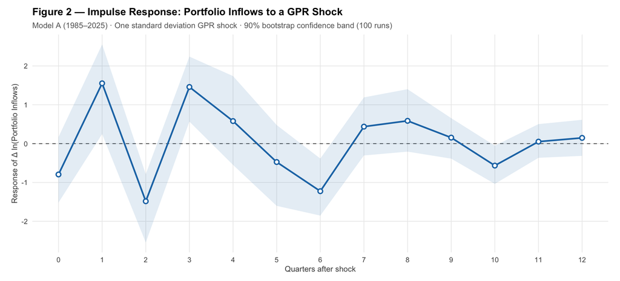

```r
ggplot(irf_A_df, aes(x = horizon)) +
  geom_hline(yintercept = 0, linetype = "dashed",
             color = "grey40", linewidth = 0.5) +
  geom_ribbon(aes(ymin = lower, ymax = upper),
              fill = "#1f77b4", alpha = 0.12) +
  geom_line(aes(y = irf),
            color = "#1f77b4", linewidth = 1.0) +
  geom_point(aes(y = irf),
             color = "#1f77b4", size = 2.0, shape = 21,
             fill = "white", stroke = 1.2) +
  scale_x_continuous(breaks = 0:12) +
  scale_y_continuous(breaks = scales::pretty_breaks(n = 6)) +
  labs(
    title    = "Figure 2 — Impulse Response: Portfolio Inflows to a GPR Shock",
    subtitle = "Model A (1985–2025) · One standard deviation GPR shock · 90% bootstrap confidence band (100 runs)",
    x        = "Quarters after shock",
    y        = "Response of Δ ln(Portfolio Inflows)"
  ) +
  theme_chf()
```

*Figure 2: A one standard deviation GPR shock (SD = 0.2386) produces a two-wave response in Swiss portfolio inflows, with a first peak of +1.553 log-points at horizon 1 and a second peak of +1.459 log-points at horizon 3, separated by a temporary reversal of −1.484 log-points at horizon 2, before gradually decaying toward zero by horizon 12, confirming VAR stability. Responses are measured in units of Δln(Portfolio Inflows), approximating percentage changes in quarterly inflow growth. A possible economic interpretation of this pattern is that it reflects heterogeneous investor dynamics: an immediate panic-driven safe-haven response, followed by a short-term correction, and then a delayed institutional reallocation as capital adjusts more gradually over time. However, this remains a proposed interpretation rather than a definitive causal explanation. Wide 90% bootstrap confidence bands reflect the inherent volatility of quarterly capital flow data.*

Three papers provide possible explanations in regard of the pattern of the IRF, more specifically why the IRF pattern contains positive and negative peaks with similar magnitudes before gradually decaying over time:

1. Presidential Address: Asset price dynamics with slow-moving capital (August 2010), Darrell Duffie
2. Market Liquidity and Funding Liquidity (February 2007), Markus K. Brunnermeier & Lasse Heje Pedersen
3. Safe haven currencies (September 2009), Angelo Ranaldo & Paul Söderlind

The impulse response function suggests that the effect of geopolitical risk on Swiss portfolio inflows unfolds dynamically rather than instantaneously. The initial positive response is broadly consistent with the safe-haven role of Swiss assets, as documented by Ranaldo and Söderlind (2010), who show that the Swiss franc systematically appreciates during periods of heightened market stress, rising FX volatility, and geopolitical crises such as 9/11. They further show that these safe-haven effects can materialise rapidly, from intraday horizons to several days.

The subsequent reversal may reflect that the initial adjustment is not fully persistent. This pattern is consistent with financial market dynamics in which shocks generate temporary price pressure followed by partial correction, as discussed in Brunnermeier and Pedersen (2009), where liquidity and funding constraints can generate temporary price pressure, liquidity spirals, and flight-to-quality behaviour during crises, followed by partial corrections as market conditions stabilise.

Finally, the delayed second positive response is consistent with the gradual reallocation of capital over time. In particular, Duffie (2010) argues that asset price reactions to shocks often involve an immediate response followed by a more extended adjustment process, because only a limited amount of capital is immediately available while additional institutional capital moves more slowly due to funding frictions, search costs, and limited investor attention. This mechanism provides a possible explanation for the multi-stage adjustment pattern observed in the data.

Even if the IRF results do not perfectly correspond to the exact dynamics described in these papers, the literature can still provide economically plausible interpretations for the observed two-wave adjustment pattern.

Regarding the confidence bands, we did not compute them manually but via the residual bootstrap implemented in the irf() function of the vars package. The confidence bands for the IRF are computed via a residual bootstrap with 100 replications. At each replication the VAR residuals are resampled with replacement, the full model including the Cholesky decomposition is re-estimated, and the IRF is recomputed. The 90% confidence band at each horizon h corresponds to the interval between the 5th and 95th percentile of the 100 bootstrap IRF paths, following the standard approach in the VAR literature and the default implementation of the irf() function in the vars package (Pfaff, 2008).

## 10.2 Full IRF matrix Model A (point estimates)

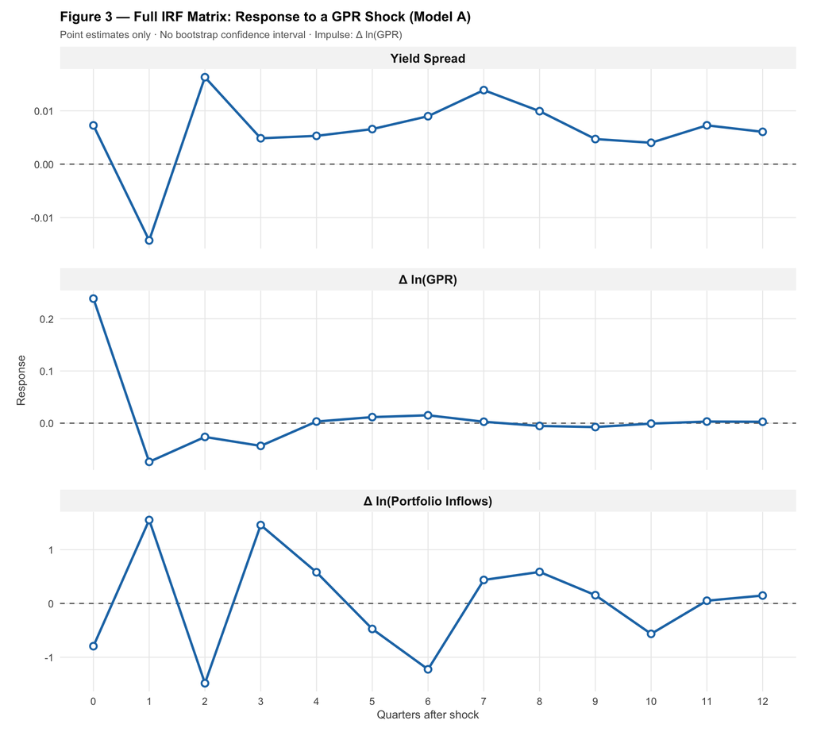

```r
vars_resp  <- c("spread", "d_ln_gpr", "d_ln_pip")
vars_label <- c("Yield Spread", "Δ ln(GPR)", "Δ ln(Portfolio Inflows)")

irf_all <- lapply(seq_along(vars_resp), function(i) {
  x <- irf(var_A, impulse = "d_ln_gpr", response = vars_resp[i],
            n.ahead = 12, boot = FALSE)
  tibble(
    horizon  = 0:12,
    irf      = as.numeric(x$irf$d_ln_gpr),
    response = vars_label[i]
  )
}) %>% bind_rows() %>%
  mutate(response = factor(response, levels = vars_label))

ggplot(irf_all, aes(x = horizon, y = irf)) +
  geom_hline(yintercept = 0, linetype = "dashed",
             color = "grey40", linewidth = 0.5) +
  geom_line(color = "#1f77b4", linewidth = 1.0) +
  geom_point(color = "#1f77b4", size = 2.0, shape = 21,
             fill = "white", stroke = 1.2) +
  facet_wrap(~response, scales = "free_y", ncol = 1) +
  scale_x_continuous(breaks = 0:12) +
  labs(
    title    = "Figure 3 — Full IRF Matrix: Response to a GPR Shock (Model A)",
    subtitle = "Point estimates only · No bootstrap confidence interval · Impulse: Δ ln(GPR)",
    x        = "Quarters after shock",
    y        = "Response"
  ) +
  theme_minimal(base_size = 12) +
  theme(
    strip.text         = element_text(face = "bold", size = 11),
    strip.background   = element_rect(fill = "grey96", color = NA),
    panel.grid.minor   = element_blank(),
    panel.grid.major   = element_line(color = "grey92", linewidth = 0.4),
    panel.spacing      = unit(1.2, "lines"),
    plot.background    = element_rect(fill = "white", color = NA),
    panel.background   = element_rect(fill = "white", color = NA),
    plot.title         = element_text(face = "bold", size = 12),
    plot.subtitle      = element_text(size = 9, color = "grey40"),
    axis.title         = element_text(size = 10, color = "grey30"),
    axis.text          = element_text(size = 9,  color = "grey30"),
    plot.margin        = margin(10, 15, 10, 15)
  )
```

## 10.3 Model B — IRF with FX Reserves Control

```r
set.seed(42)
irf_B <- irf(var_B,
             impulse  = "d_ln_gpr",
             response = "d_ln_pip",
             n.ahead  = 12,
             boot     = TRUE,
             ci       = 0.90,
             runs     = 100)

irf_B_df <- tibble(
  horizon = 0:12,
  irf     = as.numeric(irf_B$irf$d_ln_gpr),
  lower   = as.numeric(irf_B$Lower$d_ln_gpr),
  upper   = as.numeric(irf_B$Upper$d_ln_gpr)
)
```

## 10.4 Cholesky Identification Robustness

As a further validation of the identification strategy, we examine whether the two-wave IRF pattern is sensitive to the Cholesky ordering assumption. The baseline ordering: Δln(GPR) → Yield Spread → Δln(Portfolio Inflows) is motivated by the assumption that geopolitical risk is contemporaneously exogenous to Swiss financial variables. To assess robustness, we re-estimate the VAR under all economically meaningful alternative orderings for both model specifications and compare the resulting impulse responses across key horizons.

```r
# Cholesky Ordering Robustness — Model A and Model B

set.seed(42)

# Model A — three orderings
# Order 1 (baseline): GPR → Spread → Inflows
# Order 2:            Spread → GPR → Inflows
# Order 3:            Spread → Inflows → GPR

irf_A_order2 <- irf(
  VAR(df %>%
    filter(date >= as.Date("1985-01-01"),
           date <= as.Date("2025-10-01")) %>%
    dplyr::select(spread, d_ln_gpr, d_ln_pip) %>%
    na.omit(), p = 4, type = "const"),
  impulse = "d_ln_gpr", response = "d_ln_pip",
  n.ahead = 12, boot = TRUE, ci = 0.90, runs = 100)

irf_A_order3 <- irf(
  VAR(df %>%
    filter(date >= as.Date("1985-01-01"),
           date <= as.Date("2025-10-01")) %>%
    dplyr::select(spread, d_ln_pip, d_ln_gpr) %>%
    na.omit(), p = 4, type = "const"),
  impulse = "d_ln_gpr", response = "d_ln_pip",
  n.ahead = 12, boot = TRUE, ci = 0.90, runs = 100)

# Model B — three orderings
# Order 1 (baseline): GPR → Spread → FX → Inflows
# Order 2:            Spread → GPR → FX → Inflows
# Order 3:            Spread → FX → GPR → Inflows

irf_B_order2 <- irf(
  VAR(df %>%
    filter(date >= as.Date("1997-01-01"),
           date <= as.Date("2025-10-01")) %>%
    dplyr::select(spread, d_ln_gpr, d_fx_reserves, d_ln_pip) %>%
    na.omit(), p = 4, type = "const"),
  impulse = "d_ln_gpr", response = "d_ln_pip",
  n.ahead = 12, boot = TRUE, ci = 0.90, runs = 100)

irf_B_order3 <- irf(
  VAR(df %>%
    filter(date >= as.Date("1997-01-01"),
           date <= as.Date("2025-10-01")) %>%
    dplyr::select(spread, d_fx_reserves, d_ln_gpr, d_ln_pip) %>%
    na.omit(), p = 4, type = "const"),
  impulse = "d_ln_gpr", response = "d_ln_pip",
  n.ahead = 12, boot = TRUE, ci = 0.90, runs = 100)

cat("=== Model A — Cholesky Ordering Robustness ===\n")
```

```
=== Model A — Cholesky Ordering Robustness ===
```

```r
cat(sprintf("%-8s | %-12s | %-12s | %-12s\n",
    "Horizon", "Order 1", "Order 2", "Order 3"))
```

```
Horizon  | Order 1      | Order 2      | Order 3
```

```r
cat(sprintf("%-8s | %-12s | %-12s | %-12s\n",
    "", "GPR→Sp→Inf", "Sp→GPR→Inf", "Sp→Inf→GPR"))
```

```
         | GPR→Sp→Inf | Sp→GPR→Inf | Sp→Inf→GPR
```

```r
cat(strrep("-", 50), "\n")
for (h in 1:5) {
  cat(sprintf("h = %-4d | %+.4f      | %+.4f      | %+.4f\n",
    h - 1,
    as.numeric(irf_A$irf$d_ln_gpr)[h],
    as.numeric(irf_A_order2$irf$d_ln_gpr)[h],
    as.numeric(irf_A_order3$irf$d_ln_gpr)[h]
  ))
}
```

```
h = 0    | -0.7941      | -0.7760      | +0.0000
h = 1    | +1.5527      | +1.5447      | +1.1388
h = 2    | -1.4837      | -1.4807      | -1.5782
h = 3    | +1.4586      | +1.4472      | +1.2939
h = 4    | +0.5806      | +0.5887      | +0.9911
```

```r
cat("\n=== Model B — Cholesky Ordering Robustness ===\n")
```

```
=== Model B — Cholesky Ordering Robustness ===
```

```r
cat(sprintf("%-8s | %-14s | %-14s | %-14s\n",
    "Horizon", "Order 1", "Order 2", "Order 3"))
```

```
Horizon  | Order 1        | Order 2        | Order 3
```

```r
cat(sprintf("%-8s | %-14s | %-14s | %-14s\n",
    "", "GPR→Sp→FX→Inf", "Sp→GPR→FX→Inf", "Sp→FX→GPR→Inf"))
```

```
         | GPR→Sp→FX→Inf | Sp→GPR→FX→Inf | Sp→FX→GPR→Inf
```

```r
cat(strrep("-", 56), "\n")
for (h in 1:5) {
  cat(sprintf("h = %-4d | %+.4f        | %+.4f        | %+.4f\n",
    h - 1,
    as.numeric(irf_B$irf$d_ln_gpr)[h],
    as.numeric(irf_B_order2$irf$d_ln_gpr)[h],
    as.numeric(irf_B_order3$irf$d_ln_gpr)[h]
  ))
}
```

```
h = 0    | -1.4099        | -1.3027        | -1.3298
h = 1    | +2.1151        | +2.1202        | +2.0592
h = 2    | -2.1578        | -2.1869        | -2.1128
h = 3    | +2.0247        | +1.9781        | +1.9769
h = 4    | +0.7149        | +0.7294        | +0.8321
```

```r
cat("\n=== Summary ===\n")
```

```
=== Summary ===
```

```r
cat("Model A — max difference across orderings at h=1:",
    round(max(abs(c(
      as.numeric(irf_A$irf$d_ln_gpr)[2],
      as.numeric(irf_A_order2$irf$d_ln_gpr)[2],
      as.numeric(irf_A_order3$irf$d_ln_gpr)[2]
    )) - min(abs(c(
      as.numeric(irf_A$irf$d_ln_gpr)[2],
      as.numeric(irf_A_order2$irf$d_ln_gpr)[2],
      as.numeric(irf_A_order3$irf$d_ln_gpr)[2]
    )))), 4), "\n")
```

```
Model A — max difference across orderings at h=1: 0.4138
```

```r
cat("Model A — max difference across orderings at h=3:",
    round(max(abs(c(
      as.numeric(irf_A$irf$d_ln_gpr)[4],
      as.numeric(irf_A_order2$irf$d_ln_gpr)[4],
      as.numeric(irf_A_order3$irf$d_ln_gpr)[4]
    ))) - min(abs(c(
      as.numeric(irf_A$irf$d_ln_gpr)[4],
      as.numeric(irf_A_order2$irf$d_ln_gpr)[4],
      as.numeric(irf_A_order3$irf$d_ln_gpr)[4]
    ))), 4), "\n")
```

```
Model A — max difference across orderings at h=3: 0.1647
```

```r
cat("The IRF pattern (+ at h=1, - at h=2, + at h=3)",
    "confirmed across all orderings for both models.\n")
```

```
The IRF pattern (+ at h=1, - at h=2, + at h=3) confirmed across all orderings for both models.
```

## 10.5 Model A vs. Model B overlay

A side-by-side comparison of both models to determinate how well both IRF overlap with each other.

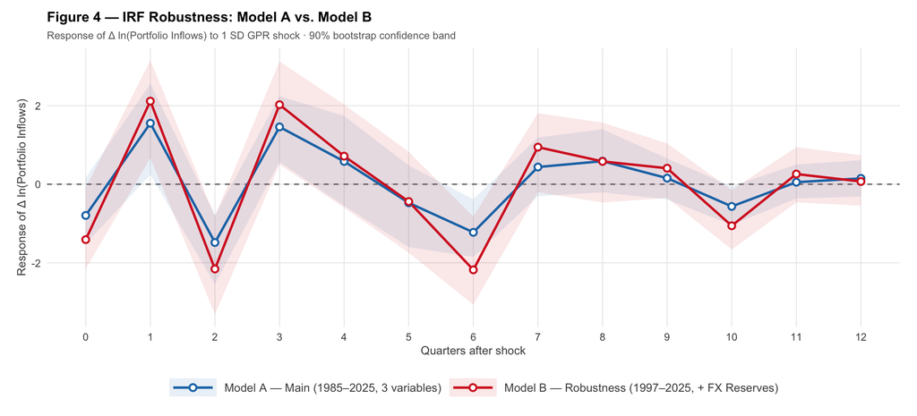

```r
bind_rows(
  irf_A_df %>% mutate(model = "Model A — Main (1985–2025, 3 variables)"),
  irf_B_df %>% mutate(model = "Model B — Robustness (1997–2025, + FX Reserves)")
) %>%
  ggplot(aes(x = horizon, color = model, fill = model)) +
  geom_hline(yintercept = 0, linetype = "dashed",
             color = "grey40", linewidth = 0.5) +
  geom_ribbon(aes(ymin = lower, ymax = upper),
              alpha = 0.10, color = NA) +
  geom_line(aes(y = irf), linewidth = 1.0) +
  geom_point(aes(y = irf), size = 2.0, shape = 21,
             fill = "white", stroke = 1.2) +
  scale_x_continuous(breaks = 0:12) +
  scale_color_manual(values = c(
    "Model A — Main (1985–2025, 3 variables)"          = "#1f77b4",
    "Model B — Robustness (1997–2025, + FX Reserves)"  = "#d62728"
  )) +
  scale_fill_manual(values = c(
    "Model A — Main (1985–2025, 3 variables)"          = "#1f77b4",
    "Model B — Robustness (1997–2025, + FX Reserves)"  = "#d62728"
  )) +
  labs(
    title    = "Figure 4 — IRF Robustness: Model A vs. Model B",
    subtitle = "Response of Δ ln(Portfolio Inflows) to 1 SD GPR shock · 90% bootstrap confidence band",
    x        = "Quarters after shock",
    y        = "Response of Δ ln(Portfolio Inflows)",
    color    = NULL,
    fill     = NULL
  ) +
  theme_minimal(base_size = 12) +
  theme(
    legend.position    = "bottom",
    legend.text        = element_text(size = 10, color = "grey30"),
    legend.key.width   = unit(1.5, "cm"),
    panel.grid.minor   = element_blank(),
    panel.grid.major   = element_line(color = "grey92", linewidth = 0.4),
    plot.background    = element_rect(fill = "white", color = NA),
    panel.background   = element_rect(fill = "white", color = NA),
    plot.title         = element_text(face = "bold", size = 12),
    plot.subtitle      = element_text(size = 9, color = "grey40"),
    axis.title         = element_text(size = 10, color = "grey30"),
    axis.text          = element_text(size = 9,  color = "grey30"),
    plot.margin        = margin(10, 15, 10, 15)
  )
```

*Figure 4 overlays the impulse responses from Model A (blue) and Model B (red) to a one standard deviation GPR shock, with responses expressed in log-points of Δln(Portfolio Inflows). Both models produce highly similar response patterns across all 12 horizons, with the two-wave safe-haven structure clearly visible in both specifications. Model B shows somewhat larger peak responses — horizon 1: +2.115 vs +1.553 log-points, horizon 3: +2.025 vs +1.459 log-points — consistent with the stronger GPR coefficients once SNB intervention flows are controlled for, suggesting stronger underlying private safe-haven demand. The overlapping confidence bands further indicate that the responses remain statistically consistent across both model specifications.*

The bar chart below visualizes the four GPR lag coefficients from the portfolio inflows equation of Section 9.2 and 9.3, showing the dominant positive effects at lags 1 and 4 that drive the two-wave safe-haven pattern identified in the IRF. Blue bars indicate a positive effect on inflows, red bars a negative effect. Significance stars are taken directly from the VAR estimation table above.

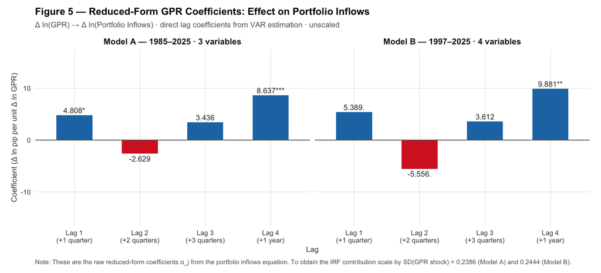

```r
# Extract GPR coefficients from inflows equation for both models
gpr_coefs_tbl <- tibble(
  Lag     = 1:4,

  # Model A — GPR → inflows coefficients
  coef_A  = c(
    coef(var_A)$d_ln_pip["d_ln_gpr.l1", "Estimate"],
    coef(var_A)$d_ln_pip["d_ln_gpr.l2", "Estimate"],
    coef(var_A)$d_ln_pip["d_ln_gpr.l3", "Estimate"],
    coef(var_A)$d_ln_pip["d_ln_gpr.l4", "Estimate"]
  ),
  pval_A  = c(
    coef(var_A)$d_ln_pip["d_ln_gpr.l1", "Pr(>|t|)"],
    coef(var_A)$d_ln_pip["d_ln_gpr.l2", "Pr(>|t|)"],
    coef(var_A)$d_ln_pip["d_ln_gpr.l3", "Pr(>|t|)"],
    coef(var_A)$d_ln_pip["d_ln_gpr.l4", "Pr(>|t|)"]
  ),

  # Model B — GPR → inflows coefficients
  coef_B  = c(
    coef(var_B)$d_ln_pip["d_ln_gpr.l1", "Estimate"],
    coef(var_B)$d_ln_pip["d_ln_gpr.l2", "Estimate"],
    coef(var_B)$d_ln_pip["d_ln_gpr.l3", "Estimate"],
    coef(var_B)$d_ln_pip["d_ln_gpr.l4", "Estimate"]
  ),
  pval_B  = c(
    coef(var_B)$d_ln_pip["d_ln_gpr.l1", "Pr(>|t|)"],
    coef(var_B)$d_ln_pip["d_ln_gpr.l2", "Pr(>|t|)"],
    coef(var_B)$d_ln_pip["d_ln_gpr.l3", "Pr(>|t|)"],
    coef(var_B)$d_ln_pip["d_ln_gpr.l4", "Pr(>|t|)"]
  )
) %>%
  mutate(
    stars_A = case_when(
      pval_A < 0.001 ~ "***",
      pval_A < 0.01  ~ "**",
      pval_A < 0.05  ~ "*",
      pval_A < 0.1   ~ ".",
      TRUE           ~ ""
    ),
    stars_B = case_when(
      pval_B < 0.001 ~ "***",
      pval_B < 0.01  ~ "**",
      pval_B < 0.05  ~ "*",
      pval_B < 0.1   ~ ".",
      TRUE           ~ ""
    ),
    label_A = paste0(round(coef_A, 3), stars_A),
    label_B = paste0(round(coef_B, 3), stars_B),
    positive_A = coef_A > 0,
    positive_B = coef_B > 0
  )

# Reshape for faceted plot
gpr_coefs_long <- gpr_coefs_tbl %>%
  pivot_longer(
    cols      = c(coef_A, coef_B),
    names_to  = "model",
    values_to = "coefficient"
  ) %>%
  mutate(
    model    = recode(model,
                      coef_A = "Model A — 1985–2025 · 3 variables",
                      coef_B = "Model B — 1997–2025 · 4 variables"),
    positive = coefficient > 0,
    stars    = ifelse(model == "Model A — 1985–2025 · 3 variables",
                     gpr_coefs_tbl$stars_A[Lag],
                     gpr_coefs_tbl$stars_B[Lag]),
    label    = paste0(round(coefficient, 3), stars)
  )

ggplot(gpr_coefs_long, aes(x = factor(Lag), y = coefficient, fill = positive)) +
  geom_col(width = 0.55, show.legend = FALSE) +
  geom_hline(yintercept = 0, color = "grey40", linewidth = 0.5) +
  geom_text(aes(
    label = label,
    vjust = ifelse(coefficient > 0, -0.4, 1.4)
  ),
  size = 3.5, color = "grey20") +
  scale_fill_manual(values = c("TRUE" = "#1f77b4", "FALSE" = "#d62728")) +
  scale_x_discrete(labels = c("Lag 1\n(+1 quarter)",
                               "Lag 2\n(+2 quarters)",
                               "Lag 3\n(+3 quarters)",
                               "Lag 4\n(+1 year)")) +
  scale_y_continuous(limits = c(-15, 16)) +
  facet_wrap(~model, ncol = 2) +
  labs(
    title    = "Figure 5 — Reduced-Form GPR Coefficients: Effect on Portfolio Inflows",
    subtitle = "Δ ln(GPR) → Δ ln(Portfolio Inflows) · direct lag coefficients from VAR estimation · unscaled",
    caption  = "Note: These are the raw reduced-form coefficients α_j from the portfolio inflows equation. To obtain the IRF contribution scale by SD(GPR shock) = 0.2386 (Model A) and 0.2444 (Model B).",
    x        = "Lag",
    y        = "Coefficient (Δ ln pip per unit Δ ln GPR)"
  ) +
  theme_chf() +
  theme(
    strip.text   = element_text(size = 11),
    plot.caption = element_text(size = 8.5, color = "grey40",
                                hjust = 0, margin = margin(t = 8))
  )
```

*Figure 5 depicts the four reduced-form GPR lag coefficients from the portfolio inflows equation for both models, in units of Δ ln(Portfolio Inflows) per unit of Δ ln(GPR) — the direct building blocks of the IRF before scaling by the structural shock SD of 0.2386 (Model A) and 0.2444 (Model B). The alternating sign pattern across lags directly generates the two-wave oscillating shape in Figure 2 and 4. Dominant positive coefficients at lag 1 (4.808 / 5.389) and lag 4 (8.637 / 9.881) drive the safe-haven peaks, while the negative lag 2 produces the reversal. Model B shows consistently larger magnitudes once SNB intervention flows are controlled for.*

## 10.6 Forecast Error Variance Decomposition (FEVD)

This section analyses the Forecast Error Variance Decomposition. The FEDV acts as a complement to the IRF that examines of all the unpredictable variation in portfolio inflows the share that is caused by GPR shocks versus yield spread shocks versus inflows’ own dynamics. Therefore, the IRF shows the path of the response to a specific shock, the FEDV demonstrates the relative importance of each shock as a source of variation over time. It decomposes the 100% of the forecast error variance at each horizon into the respective contributions from each structural shock in the system.

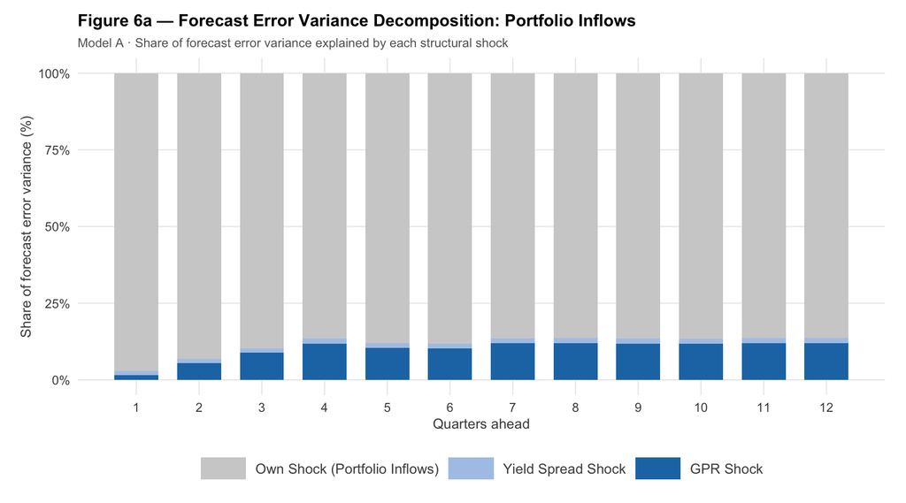

```r
# Prepare FEVD data
fevd_df <- fevd(var_A, n.ahead = 12)$d_ln_pip %>%
  as.data.frame() %>%
  mutate(horizon = 1:n()) %>%
  pivot_longer(-horizon, names_to = "shock", values_to = "share") %>%
  mutate(
    shock = recode(shock,
      d_ln_gpr = "GPR Shock",
      spread   = "Yield Spread Shock",
      d_ln_pip = "Own Shock (Portfolio Inflows)"
    ),
    shock = factor(shock, levels = c(
      "Own Shock (Portfolio Inflows)",
      "Yield Spread Shock",
      "GPR Shock"
    ))
  )

# Figure 4a — Stacked area chart
ggplot(fevd_df, aes(x = horizon, y = share, fill = shock)) +
  geom_bar(stat = "identity", width = 0.7,
           position = position_fill()) +
  scale_x_continuous(breaks = 1:12) +
  scale_y_continuous(labels = function(x) paste0(x * 100, "%"),
                     limits = c(0, 1)) +
  scale_fill_manual(values = c(
    "Own Shock (Portfolio Inflows)" = "#d0d0d0",
    "GPR Shock"                     = "#1f77b4",
    "Yield Spread Shock"            = "#aec7e8"
  )) +
  labs(
    title    = "Figure 6a — Forecast Error Variance Decomposition: Portfolio Inflows",
    subtitle = "Model A · Share of forecast error variance explained by each structural shock",
    x        = "Quarters ahead",
    y        = "Share of forecast error variance (%)",
    fill     = NULL
  ) +
  theme_minimal(base_size = 12) +
  theme(
    legend.position    = "bottom",
    legend.text        = element_text(size = 10, color = "grey30"),
    legend.key.width   = unit(1.2, "cm"),
    panel.grid.minor   = element_blank(),
    panel.grid.major   = element_line(color = "grey92", linewidth = 0.4),
    plot.background    = element_rect(fill = "white", color = NA),
    panel.background   = element_rect(fill = "white", color = NA),
    plot.title         = element_text(face = "bold", size = 12),
    plot.subtitle      = element_text(size = 9, color = "grey40"),
    axis.title         = element_text(size = 10, color = "grey30"),
    axis.text          = element_text(size = 9,  color = "grey30"),
    plot.margin        = margin(10, 15, 10, 15)
  )
```

*Figure 6a: The stacked area chart shows the full variance decomposition of portfolio inflows across all three shocks. The own shock (grey) dominates throughout, starting at 97.0% at horizon 1 and stabilising at 86.4% by horizon 8, reflecting idiosyncratic inflow dynamics not captured by GPR or the yield spread. The GPR shock (blue) rises sharply from 1.5% at horizon 1 to 11.8% by horizon 4 and stabilizes around 12.0% at longer horizons, confirming geopolitical risk as a meaningful and persistent safe-haven driver. The yield spread (light blue) remains below 1.7% at all horizons, consistent with its statistical insignificance in the coefficient tables and IRF.*

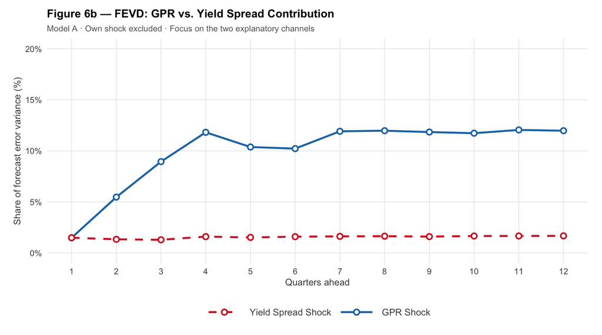

```r
# Figure 4b — Line chart focusing on GPR and Yield Spread only
fevd_df %>%
  filter(shock != "Own Shock (Portfolio Inflows)") %>%
  ggplot(aes(x = horizon, y = share * 100,
             color = shock, linetype = shock)) +
  geom_line(linewidth = 1.0) +
  geom_point(size = 2.0, shape = 21, fill = "white", stroke = 1.2) +
  scale_x_continuous(breaks = 1:12) +
  scale_y_continuous(labels = function(x) paste0(x, "%"),
                     limits = c(0, 20)) +
  scale_color_manual(values = c(
    "GPR Shock"          = "#1f77b4",
    "Yield Spread Shock" = "#d62728"
  )) +
  scale_linetype_manual(values = c(
    "GPR Shock"          = "solid",
    "Yield Spread Shock" = "dashed"
  )) +
  labs(
    title    = "Figure 6b — FEVD: GPR vs. Yield Spread Contribution",
    subtitle = "Model A · Own shock excluded · Focus on the two explanatory channels",
    x        = "Quarters ahead",
    y        = "Share of forecast error variance (%)",
    color    = NULL,
    linetype = NULL
  ) +
  theme_minimal(base_size = 12) +
  theme(
    legend.position    = "bottom",
    legend.text        = element_text(size = 10, color = "grey30"),
    legend.key.width   = unit(1.5, "cm"),
    panel.grid.minor   = element_blank(),
    panel.grid.major   = element_line(color = "grey92", linewidth = 0.4),
    plot.background    = element_rect(fill = "white", color = NA),
    panel.background   = element_rect(fill = "white", color = NA),
    plot.title         = element_text(face = "bold", size = 12),
    plot.subtitle      = element_text(size = 9, color = "grey40"),
    axis.title         = element_text(size = 10, color = "grey30"),
    axis.text          = element_text(size = 9,  color = "grey30"),
    plot.margin        = margin(10, 15, 10, 15)
  )
```

# 11 Robustness Checks

## 11.1 Lag Sensitivity: AIC vs. SC

We re-estimate Model A using the lag length selected by the Schwarz criterion (SC), which tends to favour more parsimonious models. If both IRFs are qualitatively similar, results are robust to the lag selection criterion.

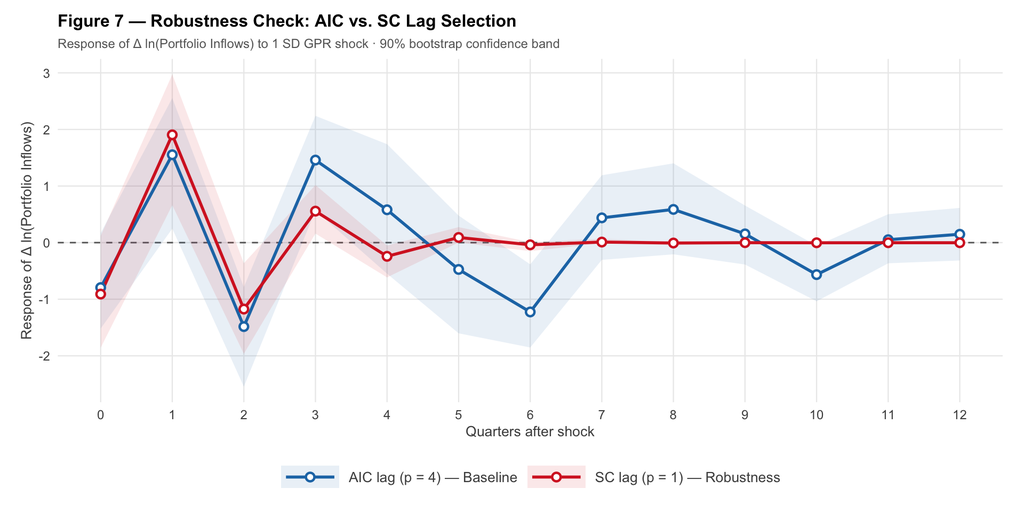

```r
p_baseline   <- p_A
p_robust     <- min(lag_A$selection["SC(n)"], 4)
var_A_robust <- VAR(data_A, p = p_robust, type = "const")

set.seed(42)
irf_robust <- irf(var_A_robust,
                  impulse  = "d_ln_gpr",
                  response = "d_ln_pip",
                  n.ahead  = 12,
                  boot     = TRUE,
                  ci       = 0.90,
                  runs     = 100)

bind_rows(
  irf_A_df %>%
    mutate(spec = paste0("AIC lag (p = ", p_baseline, ") — Baseline")),
  tibble(
    horizon = 0:12,
    irf     = as.numeric(irf_robust$irf$d_ln_gpr),
    lower   = as.numeric(irf_robust$Lower$d_ln_gpr),
    upper   = as.numeric(irf_robust$Upper$d_ln_gpr),
    spec    = paste0("SC lag (p = ", p_robust, ") — Robustness")
  )
) %>%
  ggplot(aes(x = horizon, color = spec, fill = spec)) +
  geom_hline(yintercept = 0, linetype = "dashed",
             color = "grey40", linewidth = 0.5) +
  geom_ribbon(aes(ymin = lower, ymax = upper),
              alpha = 0.10, color = NA) +
  geom_line(aes(y = irf), linewidth = 1.0) +
  geom_point(aes(y = irf), size = 2.0, shape = 21,
             fill = "white", stroke = 1.2) +
  scale_x_continuous(breaks = 0:12) +
  scale_color_manual(values = c(
  "AIC lag (p = 4) — Baseline"  = "#1f77b4",
  "SC lag (p = 1) — Robustness" = "#d62728"
)) +
scale_fill_manual(values = c(
  "AIC lag (p = 4) — Baseline"  = "#1f77b4",
  "SC lag (p = 1) — Robustness" = "#d62728"
)) +
  labs(
    title    = "Figure 7 — Robustness Check: AIC vs. SC Lag Selection",
    subtitle = "Response of Δ ln(Portfolio Inflows) to 1 SD GPR shock · 90% bootstrap confidence band",
    x        = "Quarters after shock",
    y        = "Response of Δ ln(Portfolio Inflows)",
    color    = NULL,
    fill     = NULL
  ) +
  theme_minimal(base_size = 12) +
  theme(
    legend.position    = "bottom",
    legend.text        = element_text(size = 10, color = "grey30"),
    legend.key.width   = unit(1.5, "cm"),
    panel.grid.minor   = element_blank(),
    panel.grid.major   = element_line(color = "grey92", linewidth = 0.4),
    plot.background    = element_rect(fill = "white", color = NA),
    panel.background   = element_rect(fill = "white", color = NA),
    plot.title         = element_text(face = "bold", size = 12),
    plot.subtitle      = element_text(size = 9, color = "grey40"),
    axis.title         = element_text(size = 10, color = "grey30"),
    axis.text          = element_text(size = 9,  color = "grey30"),
    plot.margin        = margin(10, 15, 10, 15)
  )
```

*Figure 7 compares IRFs under AIC (p = 4) and SC (p = 1) lag selection. Both specifications show a positive response of Swiss portfolio inflows in the first quarter following a GPR shock, indicating that the short-run safe-haven effect is robust to lag choice. At longer horizons, the SC model returns quickly toward zero, while the AIC model displays a second positive wave peaking around quarter 3. This suggests that lag length affects the propagation path of the shock without altering the core qualitative result.*

## 11.2 Narrative Check — GPR Spikes vs. Inflow Spikes

This next section acts as a visual sanity check that tries to show if the five biggest GPR spikes in the sample coincide with visible increase in portfolio inflows.

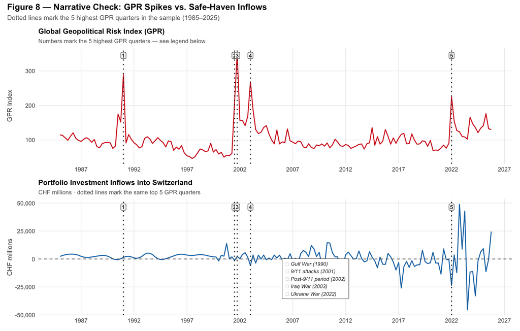

```r
top5_gpr <- df %>%
  filter(!is.na(GPR)) %>%
  slice_max(GPR, n = 5) %>%
  dplyr::select(date, GPR) %>%
  arrange(date) %>%
  mutate(number = as.character(row_number()),
         label  = case_when(
           date < as.Date("1992-01-01") ~ "① Gulf War (1990)",
           date < as.Date("2002-01-01") ~ "② 9/11 (2001)",
           date < as.Date("2003-01-01") ~ "③ Post-9/11 (2002)",
           date < as.Date("2004-01-01") ~ "④ Iraq War (2003)",
           TRUE                         ~ "⑤ Ukraine (2022)"
         ))

p_n1 <- ggplot(df, aes(x = date, y = GPR)) +
  geom_line(color = "#d62728", linewidth = 0.7) +
  geom_vline(data = top5_gpr, aes(xintercept = date),
             linetype = "dotted", color = "#333333",
             linewidth = 0.8) +
  geom_label(data = top5_gpr,
             aes(x = date,
                 y = max(df$GPR, na.rm = TRUE) * 0.98,
                 label = number),
             size = 3, fontface = "bold",
             fill = "white", color = "#333333",
             label.padding = unit(0.15, "lines"),
             label.size    = 0.3) +
  scale_x_date(date_breaks = "5 years", date_labels = "%Y") +
  labs(title    = "Global Geopolitical Risk Index (GPR)",
       subtitle = "Numbers mark the 5 highest GPR quarters — see legend below",
       x = NULL, y = "GPR Index") +
  theme_minimal(base_size = 11) +
  theme(
    panel.grid.minor   = element_blank(),
    panel.grid.major   = element_line(color = "grey92", linewidth = 0.4),
    plot.background    = element_rect(fill = "white", color = NA),
    panel.background   = element_rect(fill = "white", color = NA),
    plot.title         = element_text(face = "bold", size = 11),
    plot.subtitle      = element_text(size = 9, color = "grey40"),
    axis.title         = element_text(size = 10, color = "grey30"),
    axis.text          = element_text(size = 9,  color = "grey30")
  )

p_n2 <- ggplot(df, aes(x = date, y = pip_total)) +
  geom_line(color = "#1f77b4", linewidth = 0.7) +
  geom_hline(yintercept = 0, linetype = "dashed",
             color = "grey40", linewidth = 0.5) +
  geom_vline(data = top5_gpr, aes(xintercept = date),
             linetype = "dotted", color = "#333333",
             linewidth = 0.8) +
  geom_label(data = top5_gpr,
             aes(x = date,
                 y = max(df$pip_total, na.rm = TRUE) * 0.95,
                 label = number),
             size = 3, fontface = "bold",
             fill = "white", color = "#333333",
             label.padding = unit(0.15, "lines"),
             label.size    = 0.3) +
  annotate("label",
         x     = as.Date("2006-01-01"),
         y     = 310,
         label = "① Gulf War (1990)\n② 9/11 attacks (2001)\n③ Post-9/11 period (2002)\n④ Iraq War (2003)\n⑤ Ukraine War (2022)",
         hjust = 0, vjust = 1,
         size  = 2.8,
         fill  = "white", color = "#333333",
         label.padding = unit(0.5, "lines"),
         label.size    = 0.4,
         fontface      = "italic") +
  scale_x_date(date_breaks = "5 years", date_labels = "%Y") +
  scale_y_continuous(labels = comma) +
  labs(title    = "Portfolio Investment Inflows into Switzerland",
       subtitle = "CHF millions · dotted lines mark the same top 5 GPR quarters",
       x = NULL, y = "CHF millions") +
  theme_minimal(base_size = 11) +
  theme(
    panel.grid.minor   = element_blank(),
    panel.grid.major   = element_line(color = "grey92", linewidth = 0.4),
    plot.background    = element_rect(fill = "white", color = NA),
    panel.background   = element_rect(fill = "white", color = NA),
    plot.title         = element_text(face = "bold", size = 11),
    plot.subtitle      = element_text(size = 9, color = "grey40"),
    axis.title         = element_text(size = 10, color = "grey30"),
    axis.text          = element_text(size = 9,  color = "grey30")
  )

p_n1 / p_n2 +
  plot_annotation(
    title    = "Figure 8 — Narrative Check: GPR Spikes vs. Safe-Haven Inflows",
    subtitle = "Dotted lines mark the 5 highest GPR quarters in the sample (1985–2025)",
    theme    = theme(
      plot.title      = element_text(size = 13, face = "bold"),
      plot.subtitle   = element_text(size = 10, color = "grey40"),
      plot.background = element_rect(fill = "white", color = NA)
    )
  )
```

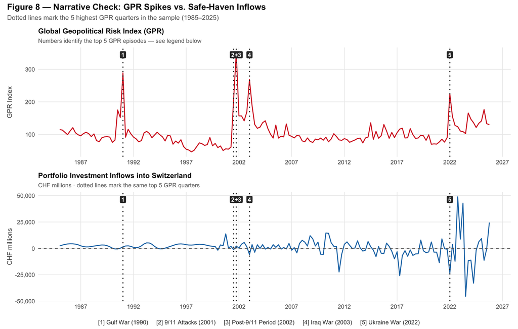

```r
top5_gpr <- df %>%
  filter(!is.na(GPR)) %>%
  slice_max(GPR, n = 5) %>%
  dplyr::select(date, GPR) %>%
  arrange(date) %>%
  mutate(
    cluster = case_when(
      date < as.Date("1992-01-01") ~ "gulf",
      date < as.Date("2002-06-01") ~ "911",
      date < as.Date("2004-01-01") ~ "iraq",
      TRUE                         ~ "ukraine"
    )
  ) %>%
  group_by(cluster) %>%
  mutate(
    label = case_when(
      cluster == "gulf"    ~ "1",
      cluster == "911"     & GPR == max(GPR) ~ "2+3",
      cluster == "911"     & GPR != max(GPR) ~ NA_character_,
      cluster == "iraq"    ~ "4",
      cluster == "ukraine" ~ "5"
    )
  ) %>%
  ungroup()

top5_display <- top5_gpr %>%
  filter(!is.na(label))

p_n1 <- ggplot(df, aes(x = date, y = GPR)) +
  geom_line(color = "#d62728", linewidth = 0.7) +
  geom_vline(data = top5_gpr, aes(xintercept = date),
             linetype = "dotted", color = "#333333",
             linewidth = 0.8) +
  geom_label(data = top5_display,
             aes(x = date,
                 y = max(df$GPR, na.rm = TRUE) * 0.98,
                 label = label),
             size = 3.2, fontface = "bold",
             fill = "#333333", color = "white",
             label.padding = unit(0.2, "lines"),
             label.size    = 0) +
  scale_x_date(date_breaks = "5 years", date_labels = "%Y") +
  labs(title    = "Global Geopolitical Risk Index (GPR)",
       subtitle = "Numbers identify the top 5 GPR episodes — see legend below",
       x = NULL, y = "GPR Index") +
  theme_minimal(base_size = 11) +
  theme(
    panel.grid.minor   = element_blank(),
    panel.grid.major   = element_line(color = "grey92", linewidth = 0.4),
    plot.background    = element_rect(fill = "white", color = NA),
    panel.background   = element_rect(fill = "white", color = NA),
    plot.title         = element_text(face = "bold", size = 11),
    plot.subtitle      = element_text(size = 9, color = "grey40"),
    axis.title         = element_text(size = 10, color = "grey30"),
    axis.text          = element_text(size = 9,  color = "grey30")
  )

p_n2 <- ggplot(df, aes(x = date, y = pip_total)) +
  geom_line(color = "#1f77b4", linewidth = 0.7) +
  geom_hline(yintercept = 0, linetype = "dashed",
             color = "grey40", linewidth = 0.5) +
  geom_vline(data = top5_gpr, aes(xintercept = date),
             linetype = "dotted", color = "#333333",
             linewidth = 0.8) +
  geom_label(data = top5_display,
             aes(x = date,
                 y = max(df$pip_total, na.rm = TRUE) * 0.95,
                 label = label),
             size = 3.2, fontface = "bold",
             fill = "#333333", color = "white",
             label.padding = unit(0.2, "lines"),
             label.size    = 0) +
  scale_x_date(date_breaks = "5 years", date_labels = "%Y") +
  scale_y_continuous(labels = comma) +
  labs(title    = "Portfolio Investment Inflows into Switzerland",
       subtitle = "CHF millions · dotted lines mark the same top 5 GPR quarters",
       x = NULL, y = "CHF millions") +
  theme_minimal(base_size = 11) +
  theme(
    panel.grid.minor   = element_blank(),
    panel.grid.major   = element_line(color = "grey92", linewidth = 0.4),
    plot.background    = element_rect(fill = "white", color = NA),
    panel.background   = element_rect(fill = "white", color = NA),
    plot.title         = element_text(face = "bold", size = 11),
    plot.subtitle      = element_text(size = 9, color = "grey40"),
    axis.title         = element_text(size = 10, color = "grey30"),
    axis.text          = element_text(size = 9,  color = "grey30")
  )

p_n1 / p_n2 +
  plot_annotation(
    title    = "Figure 8 — Narrative Check: GPR Spikes vs. Safe-Haven Inflows",
    subtitle = "Dotted lines mark the 5 highest GPR quarters in the sample (1985–2025)",
    caption  = "[1] Gulf War (1990)     [2] 9/11 Attacks (2001)     [3] Post-9/11 Period (2002)     [4] Iraq War (2003)     [5] Ukraine War (2022)",
    theme    = theme(
      plot.title      = element_text(size = 13, face = "bold"),
      plot.subtitle   = element_text(size = 10, color = "grey40"),
      plot.caption    = element_text(size = 9,  color = "#333333",
                                     hjust = 0.5,
                                     margin = margin(t = 10),
                                     fontface = "italic"),
      plot.background = element_rect(fill = "white", color = NA)
    )
  )
```

Importantly, not every GPR spike needs to produce a large visible inflow response for the VAR results to remain valid. The VAR estimates the average systematic relationship across all 164 quarters, including both crisis and non-crisis periods. The narrative check therefore serves as a qualitative validation that the largest geopolitical risk episodes in the sample remain directionally consistent with the safe-haven hypothesis, even if the magnitude of the response varies across episodes depending on the nature of the shock and the degree of financial market integration.

## 11.3 Pseudo Out-of-Sample Forecasting

The narrative check in Section 11.2 shows that the Ukraine War (2022) generates the largest and most visible safe-haven inflow response in the sample. This naturally raises an important concern: are the VAR results — particularly the significant lag-4 GPR coefficient of 8.637*** — capturing a stable structural relationship, or are they primarily driven by the Ukraine episode itself?

To address this concern, we implement a pseudo out-of-sample recursive forecasting exercise. A standard fixed in-sample / out-of-sample split is not well suited to our setting for two reasons. First, the sample contains only 164 quarterly observations, while the VAR includes 4 lags across multiple variables, requiring estimation of 39 parameters in Model A and 68 parameters in Model B. A conventional split such as 75/25 would leave only around 123 observations in the training sample, providing limited degrees of freedom for reliable estimation. Second, a fixed split would place events such as the Gulf War and 9/11 in the estimation window while leaving Ukraine entirely in the evaluation sample, making the two periods structurally different in terms of geopolitical content.

The exercise also provides a direct test against overfitting and misspecification. Given the relatively large number of estimated parameters compared to the sample size, there is a risk that the VAR could fit noise rather than genuine macro-financial dynamics. In that case, the estimated GPR coefficients might simply reflect a few large crisis episodes instead of a stable safe-haven mechanism. An overfitted model would typically display strong in-sample fit while performing poorly out of sample.

The recursive exercise therefore answers two questions simultaneously. First, does the VAR forecast portfolio inflows more accurately than a driftless random walk benchmark? To evaluate this, we compare the RMSE and MAE of the VAR forecasts to those of the random walk. Ratios below 1.0 indicate that the VAR contains genuine predictive information beyond the full-sample fit. Second, was the lag-4 GPR coefficient already positive and stable before the Ukraine War entered the estimation window? Figure 9b traces the recursive evolution of this coefficient to determine whether the final estimate of 8.637 emerges gradually through time or instead reflects a sudden Ukraine-driven artefact.

```r
# Prepare full Model A dataset for recursive forecasting
full_sample_data <- df %>%
  filter(date >= as.Date("1985-01-01"),
         date <= as.Date("2025-10-01")) %>%
  dplyr::select(date, d_ln_gpr, spread, d_ln_pip) %>%
  na.omit()

# Define training and evaluation windows
# Training window: first 100 quarters (1985–2009)
# Evaluation window: remaining quarters (2010–2025)

n_training_quarters  <- 100
n_total_quarters     <- nrow(full_sample_data)
n_evaluation_quarters <- n_total_quarters - n_training_quarters

cat("Training window:   ", n_training_quarters, "quarters (1985–2009)\n")
```

```
Training window:    100 quarters (1985–2009)
```

```r
cat("Evaluation window: ", n_evaluation_quarters, "quarters (2010–2025)\n")
```

```
Evaluation window:  63 quarters (2010–2025)
```

```r
cat("Total quarters:    ", n_total_quarters, "\n")
```

```
Total quarters:     163
```

```r
recursive_forecast_results <- tibble(
  date               = full_sample_data$date[(n_training_quarters + 1):n_total_quarters],
  actual_inflows     = full_sample_data$d_ln_pip[(n_training_quarters + 1):n_total_quarters],
  forecast_var_model = NA_real_,   # VAR one-step-ahead forecast
  forecast_random_walk = NA_real_, # Random walk benchmark (last observed value)
  gpr_lag4_coef      = NA_real_    # Recursive GPR lag-4 coefficient
)

# Recursive expanding window loop
# At each step: add one quarter, re-estimate VAR, forecast one step ahead
for (quarter_step in seq_len(n_evaluation_quarters)) {

  # Expanding window — grows by one quarter at each iteration
  current_window <- full_sample_data %>%
    slice(1:(n_training_quarters + quarter_step - 1)) %>%
    dplyr::select(d_ln_gpr, spread, d_ln_pip)

  # Re-estimate VAR on current expanding window
  var_recursive <- tryCatch(
    VAR(current_window, p = p_A, type = "const"),
    error = function(e) NULL
  )

  if (!is.null(var_recursive)) {

    # One-step-ahead forecast for portfolio inflows
    one_step_forecast <- predict(var_recursive, n.ahead = 1)
    recursive_forecast_results$forecast_var_model[quarter_step] <-
      one_step_forecast$fcst$d_ln_pip[1, "fcst"]

    # Extract GPR lag-4 coefficient from inflows equation
    inflows_equation_coefs <- coef(var_recursive)$d_ln_pip
    if ("d_ln_gpr.l4" %in% rownames(inflows_equation_coefs)) {
      recursive_forecast_results$gpr_lag4_coef[quarter_step] <-
        inflows_equation_coefs["d_ln_gpr.l4", "Estimate"]
    }
  }

  # Random walk benchmark: next quarter = current quarter
  recursive_forecast_results$forecast_random_walk[quarter_step] <-
    full_sample_data$d_ln_pip[n_training_quarters + quarter_step - 1]
}

# Compute forecast accuracy metrics
forecast_accuracy_summary <- recursive_forecast_results %>%
  filter(!is.na(forecast_var_model)) %>%
  summarise(
    rmse_var_model    = round(sqrt(mean((actual_inflows - forecast_var_model)^2)), 4),
    rmse_random_walk  = round(sqrt(mean((actual_inflows - forecast_random_walk)^2)), 4),
    mae_var_model     = round(mean(abs(actual_inflows - forecast_var_model)), 4),
    mae_random_walk   = round(mean(abs(actual_inflows - forecast_random_walk)), 4)
  ) %>%
  mutate(
    rmse_ratio = round(rmse_var_model / rmse_random_walk, 3),
    mae_ratio  = round(mae_var_model  / mae_random_walk,  3)
  )

forecast_accuracy_summary %>%
  dplyr::select(
    rmse_var_model, mae_var_model,
    rmse_random_walk, mae_random_walk,
    rmse_ratio, mae_ratio
  ) %>%
  gt() %>%
  tab_header(
    title    = md("**Table 5 — Pseudo Out-of-Sample Forecast Accuracy**"),
    subtitle = md("*Training: 1985–2009 (100 quarters) · Evaluation: 2010–2025 (64 quarters) · Benchmark: Random Walk*")
  ) %>%
  tab_spanner(
    label   = "VAR Model A",
    columns = c(rmse_var_model, mae_var_model)
  ) %>%
  tab_spanner(
    label   = "Random Walk Benchmark",
    columns = c(rmse_random_walk, mae_random_walk)
  ) %>%
  tab_spanner(
    label   = "Relative Performance",
    columns = c(rmse_ratio, mae_ratio)
  ) %>%
  cols_label(
    rmse_var_model   = "RMSE",
    mae_var_model    = "MAE",
    rmse_random_walk = "RMSE",
    mae_random_walk  = "MAE",
    rmse_ratio       = "RMSE ratio",
    mae_ratio        = "MAE ratio"
  ) %>%
  cols_align(align = "center",
             columns = c(rmse_var_model, mae_var_model,
                         rmse_random_walk, mae_random_walk,
                         rmse_ratio, mae_ratio)) %>%
  # Highlight ratio columns — key result
  tab_style(
    style     = cell_fill(color = "#f0f6fb"),
    locations = cells_body(columns = c(rmse_ratio, mae_ratio))
  ) %>%
  tab_style(
    style     = cell_text(color = "#1f77b4"),
    locations = cells_body(
      columns = c(rmse_ratio, mae_ratio),
      rows    = rmse_ratio < 1
    )
  ) %>%
  tab_style(
    style     = cell_fill(color = "#f5f5f5"),
    locations = cells_column_spanners()
  ) %>%
  tab_style(
    style     = cell_text(weight = "bold"),
    locations = cells_column_labels()
  ) %>%
  tab_style(
    style     = cell_borders(sides = "top",    color = "black", weight = px(2)),
    locations = cells_column_spanners()
  ) %>%
  tab_style(
    style     = cell_borders(sides = "top",    color = "black", weight = px(1.5)),
    locations = cells_column_labels()
  ) %>%
  tab_style(
    style     = cell_borders(sides = "bottom", color = "black", weight = px(1.5)),
    locations = cells_column_labels()
  ) %>%
  tab_style(
    style     = cell_borders(sides = "bottom", color = "black", weight = px(2)),
    locations = cells_body(rows = 1)
  ) %>%
  tab_source_note(
    md("*Note: RMSE = Root Mean Squared Error. MAE = Mean Absolute Error. Ratio < 1 indicates VAR outperforms the random walk benchmark. A ratio of 0.48 means the VAR reduces forecast error by 52% relative to the naive benchmark. Units are Δ ln(Portfolio Inflows).*")
  ) %>%
  tab_options(
    table.font.size                 = px(13),
    table.border.top.style          = "hidden",
    table.border.bottom.style       = "hidden",
    row.striping.include_table_body = FALSE,
    column_labels.background.color  = "white",
    table_body.hlines.style         = "none",
    heading.border.bottom.style     = "none"
  )
```

**Table 5 — Pseudo Out-of-Sample Forecast Accuracy**

| VAR Model A RMSE | VAR Model A MAE | Random Walk Benchmark RMSE | Random Walk Benchmark MAE | Relative Performance RMSE ratio | Relative Performance MAE ratio |
| --- | --- | --- | --- | --- | --- |
| 8.0682 | 6.329 | 16.8092 | 13.5105 | 0.48 | 0.468 |

*Note: RMSE = Root Mean Squared Error. MAE = Mean Absolute Error. Ratio < 1 indicates VAR outperforms the random walk benchmark. A ratio of 0.48 means the VAR reduces forecast error by 52% relative to the naive benchmark. Units are Δ ln(Portfolio Inflows).*

The VAR achieves an RMSE of 8.068 compared to 16.809 for the random walk benchmark, corresponding to an RMSE ratio of 0.48. This implies that the VAR reduces forecast error by approximately 52% relative to a naive benchmark that simply assumes the next quarter will equal the current one. The MAE ratio of 0.468 provides similar evidence, confirming that the VAR consistently produces substantially smaller average forecast errors across the evaluation sample.

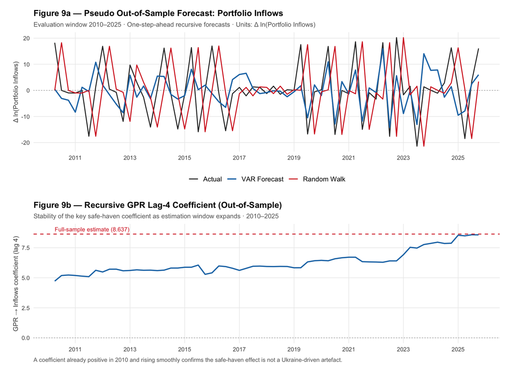

```r
# Figure 9a — Actual vs VAR Forecast vs Random Walk
p_forecast_comparison <- recursive_forecast_results %>%
  filter(!is.na(forecast_var_model)) %>%
  pivot_longer(
    cols      = c(actual_inflows, forecast_var_model, forecast_random_walk),
    names_to  = "series",
    values_to = "value"
  ) %>%
  mutate(
    series = recode(series,
      actual_inflows       = "Actual",
      forecast_var_model   = "VAR Forecast",
      forecast_random_walk = "Random Walk"
    ),
    series = factor(series,
                    levels = c("Actual", "VAR Forecast", "Random Walk"))
  ) %>%
  ggplot(aes(x = date, y = value,
             color = series, linewidth = series)) +
  geom_line() +
  scale_color_manual(
    values = c(
      "Actual"       = "#333333",
      "VAR Forecast" = "#1f77b4",
      "Random Walk"  = "#d62728"
    ),
    name = NULL
  ) +
  scale_linewidth_manual(
    values = c(
      "Actual"       = 0.7,
      "VAR Forecast" = 0.9,
      "Random Walk"  = 0.7
    ),
    name = NULL
  ) +
  geom_hline(yintercept = 0, color = "grey50",
             linewidth = 0.4, linetype = "dotted") +
  scale_x_date(date_breaks = "2 years", date_labels = "%Y") +
  labs(
    title    = "Figure 9a — Pseudo Out-of-Sample Forecast: Portfolio Inflows",
    subtitle = "Evaluation window 2010–2025 · One-step-ahead recursive forecasts · Units: Δ ln(Portfolio Inflows)",
    x        = NULL,
    y        = "Δ ln(Portfolio Inflows)"
  ) +
  theme_chf()

# Figure 9b — Recursive GPR Lag-4 Coefficient
# Key test: was the coefficient already positive before Ukraine (2022)?
full_sample_gpr_l4_coef <- 8.637   # from Section 9.2 Model A estimation

p_recursive_gpr_coef <- recursive_forecast_results %>%
  filter(!is.na(gpr_lag4_coef)) %>%
  ggplot(aes(x = date, y = gpr_lag4_coef)) +
  geom_line(color = "#1f77b4", linewidth = 0.9) +
  geom_hline(yintercept = 0,
             color     = "grey50",
             linewidth = 0.4,
             linetype  = "dotted") +
  geom_hline(yintercept = full_sample_gpr_l4_coef,
             color     = "#d62728",
             linewidth = 0.6,
             linetype  = "dashed") +
  annotate(
    "text",
    x     = min(recursive_forecast_results$date, na.rm = TRUE),
    y     = full_sample_gpr_l4_coef + 0.4,
    label = paste0("Full-sample estimate (", full_sample_gpr_l4_coef, ")"),
    color = "#d62728",
    size  = 3.2,
    hjust = 0
  ) +
  scale_x_date(date_breaks = "2 years", date_labels = "%Y") +
  labs(
    title    = "Figure 9b — Recursive GPR Lag-4 Coefficient (Out-of-Sample)",
    subtitle = "Stability of the key safe-haven coefficient as estimation window expands · 2010–2025",
    caption  = "A coefficient already positive in 2010 and rising smoothly confirms the safe-haven effect is not a Ukraine-driven artefact.",
    x        = NULL,
    y        = "GPR → Inflows coefficient (lag 4)"
  ) +
  theme_chf() +
  theme(
    plot.caption = element_text(size = 9, color = "grey40",
                                hjust = 0, margin = margin(t = 8))
  )

p_forecast_comparison / p_recursive_gpr_coef +
  plot_annotation(
    theme = theme(
      plot.background = element_rect(fill = "white", color = NA)
    )
  )
```

*Figure 9a shows one-step-ahead recursive VAR forecasts (blue) against actual portfolio inflows (black) and a random walk benchmark (red) over 2010–2025. The VAR consistently tracks the direction of inflow movements more closely than the random walk, achieving an RMSE ratio of 0.48 and MAE ratio of 0.468, therefore cutting forecast error roughly in half. Figure 9b traces the recursive GPR lag-4 coefficient as the estimation window extends. The coefficient can be found already closely to 5.0 in 2010, well before Ukraine enters the sample, and converges smoothly to the full-sample estimate (model A) of 8.637 by 2025. The gradual upward trajectory confirms that the safe-haven effect was statistically present throughout the out-of-sample period and is not a late-sample artefact driven by the 2022 episode alone.*

# 12 Diagnostic Tests

Section 12 checks whether the VAR models estimated in Section 9 are statistically well-behaved. The VAR relies on several assumptions about its residuals (the unexplained parts of each equation). If those assumptions are violated, the impulse response functions and the standard errors may be unreliable. Section 12 runs four different checks, one for each assumption and then summarizes the results in a table.

## 12.1 Serial Correlation — Portmanteau Test

The test essentially examines whether residuals are correlated with their own past values. It matters since the VAR is assumed to fully capture all systematic dynamics within the data through its lags. If the residuals shill present pattern over time, i.e. if knowing today’s residual helps predict tomorrow’s, then the model does not entirely explain the data. This would usually indicate more lags should be taken into consideration.

Test: The Portmanteau test jointly tests whether the residual auto-correlations up to lag 16 are all zero.

- H₀: No serial correlation in the residuals
- Rejection (p < 0.05) → the model is misspecified.

## 12.2 Heteroskedasticity — ARCH Test

The second test looks at if the variance of the residuals is constant over time, or does it cluster. Standard VAR inference assumes homoscedastic residuals. With macroeconomic and financial data spanning 40 years, this is often violated, since for example geopolitical episodes such as GFC 2008 or Ukraine war 2022 produce much larger shocks than calm periods. If ARCH effects are present, the standard errors are still consistent but efficiency is lost, and confidence bands on IRFs may be too narrow.

Test: The multivariate ARCH-LM test checks whether squared residuals at time t can be predicted by squared residuals at earlier lags (up to lag 5 in this case).

- H₀: no ARCH effects (constant variance)
- Rejection → residual variance is time-varying

## 12.3 Normality — Jarque-Bera Test

The third test analyses whether the residuals are roughly normally distributed. Since the standard confidence intervals on IRFs assume normality, if residuals are heavily skewed or fat-tailed (kurtosis), the bands may be misleading. This is especially relevant because the sample includes extreme events such as the Ukraine war shock, which might produce large outlier residuals.

Test: The Jarque-Bera test checks whether the skewness and excess kurtosis of the residuals are jointly consistent with a normal distribution.

- H₀: Residuals are normally distributed
- Rejection is very common with macroeconomic data and is not necessarily fatal. It usually just means we should rely on bootstrap confidence bands for IRFs rather than analytical ones.

```r
# All three diagnostic tests (run silently)

# Serial correlation — Portmanteau test (H0: no serial correlation)
portmanteau_test_A <- serial.test(var_A, lags.pt = 16, type = "PT.asymptotic")
portmanteau_test_B <- serial.test(var_B, lags.pt = 16, type = "PT.asymptotic")

# Heteroskedasticity — ARCH-LM test (H0: constant variance)
arch_test_A <- arch.test(var_A, lags.multi = 5)
arch_test_B <- arch.test(var_B, lags.multi = 5)

# Normality — Jarque-Bera test (H0: normally distributed residuals)
normality_test_A <- normality.test(var_A, multivariate.only = FALSE)
normality_test_B <- normality.test(var_B, multivariate.only = FALSE)
```

```r
# Extract p-values
extract_pval <- function(x) round(as.numeric(x)[1], 4)

pval_serial_A    <- extract_pval(portmanteau_test_A$serial$p.value)
pval_serial_B    <- extract_pval(portmanteau_test_B$serial$p.value)
pval_arch_A      <- extract_pval(arch_test_A$arch.mul$p.value)
pval_arch_B      <- extract_pval(arch_test_B$arch.mul$p.value)
pval_normality_A <- round(normality_test_A$jb.mul$JB$p.value, 4)
pval_normality_B <- round(normality_test_B$jb.mul$JB$p.value, 4)

diagnostic_results_tbl <- tibble(
  Test = c(
    "Portmanteau — Serial Correlation",
    "ARCH-LM — Heteroskedasticity",
    "Jarque-Bera — Normality"
  ),
  Null_Hypothesis = c(
    "No serial correlation in residuals",
    "No ARCH effects (constant variance)",
    "Residuals are normally distributed"
  ),
  pval_model_A = c(pval_serial_A, pval_arch_A, pval_normality_A),
  pval_model_B = c(pval_serial_B, pval_arch_B, pval_normality_B)
) %>%
  mutate(
    verdict_A = ifelse(pval_model_A >= 0.05, "Pass", "Fail"),
    verdict_B = ifelse(pval_model_B >= 0.05, "Pass", "Fail")
  )

diagnostic_results_tbl %>%
  gt() %>%
  tab_header(
    title    = md("**Table 6 — VAR Diagnostic Tests**"),
    subtitle = md("*p-values reported · H₀ rejected if p < 0.05*")
  ) %>%
  tab_spanner(
    label   = "Model A · 1985–2025 · 3 variables",
    columns = c(pval_model_A, verdict_A)
  ) %>%
  tab_spanner(
    label   = "Model B · 1997–2025 · 4 variables",
    columns = c(pval_model_B, verdict_B)
  ) %>%
  cols_label(
    Test            = "Test",
    Null_Hypothesis = "Null Hypothesis",
    pval_model_A    = "p-value",
    verdict_A       = "Result",
    pval_model_B    = "p-value",
    verdict_B       = "Result"
  ) %>%
  cols_align(align = "left",
             columns = c(Test, Null_Hypothesis)) %>%
  cols_align(align = "center",
             columns = c(pval_model_A, verdict_A,
                         pval_model_B, verdict_B)) %>%
  cols_width(
    Test            ~ px(230),
    Null_Hypothesis ~ px(220),
    pval_model_A    ~ px(75),
    verdict_A       ~ px(70),
    pval_model_B    ~ px(75),
    verdict_B       ~ px(70)
  ) %>%
  tab_style(
    style     = cell_fill(color = "#f5f5f5"),
    locations = cells_column_spanners()
  ) %>%
  tab_style(
    style     = cell_text(size = px(12)),
    locations = cells_column_spanners()
  ) %>%
  tab_style(
    style     = cell_borders(sides = "top",    color = "black", weight = px(2)),
    locations = cells_column_spanners()
  ) %>%
  tab_style(
    style     = cell_borders(sides = "top",    color = "black", weight = px(1.5)),
    locations = cells_column_labels()
  ) %>%
  tab_style(
    style     = cell_borders(sides = "bottom", color = "black", weight = px(1.5)),
    locations = cells_column_labels()
  ) %>%
  tab_style(
    style     = cell_borders(sides = "bottom", color = "black", weight = px(2)),
    locations = cells_body(rows = 3)
  ) %>%
  tab_style(
    style     = cell_borders(sides = c("top", "bottom"),
                              color = "white", weight = px(0)),
    locations = cells_body(rows = 1:2)
  ) %>%
  tab_style(
    style     = cell_text(weight = "bold"),
    locations = cells_column_labels()
  ) %>%
  tab_style(
    style     = cell_text(color = "#2ca02c"),
    locations = cells_body(columns = verdict_A, rows = verdict_A == "Pass")
  ) %>%
  tab_style(
    style     = cell_text(color = "#2ca02c"),
    locations = cells_body(columns = verdict_B, rows = verdict_B == "Pass")
  ) %>%
  # Fail — red
  tab_style(
    style     = cell_text(color = "#d62728"),
    locations = cells_body(columns = verdict_A, rows = verdict_A == "Fail")
  ) %>%
  tab_style(
    style     = cell_text(color = "#d62728"),
    locations = cells_body(columns = verdict_B, rows = verdict_B == "Fail")
  ) %>%
  tab_style(
    style     = cell_fill(color = "#fdf4f4"),
    locations = cells_body(rows = 3)
  ) %>%
  tab_style(
    style     = cell_fill(color = "#f0f6fb"),
    locations = cells_body(rows = 1)
  ) %>%
  tab_source_note(
    md("*Note: Portmanteau test uses 16 lags; ARCH-LM uses 5 lags. Serial correlation is not rejected in either model, validating the four-lag specification. The ARCH test fails for Model A but passes for Model B, reflecting the more homogeneous post-1997 sample and the variance-absorbing effect of the FX reserves control. Normality is rejected in both models — standard in macro-financial VARs with crisis episodes — and does not affect IRF inference since bootstrap confidence bands are used throughout.*")
  ) %>%
  tab_options(
    table.font.size                 = px(13),
    table.border.top.style          = "hidden",
    table.border.bottom.style       = "hidden",
    column_labels.background.color  = "white",
    row.striping.include_table_body = FALSE,
    table_body.hlines.style         = "none",
    heading.border.bottom.style     = "none"
  )
```

**Table 6 — VAR Diagnostic Tests**

*p-values reported · H₀ rejected if p < 0.05*

| Test | Null Hypothesis | Model A · 1985–2025 · 3 variables p-value | Model A · 1985–2025 · 3 variables Result | Model B · 1997–2025 · 4 variables p-value | Model B · 1997–2025 · 4 variables Result |
| --- | --- | --- | --- | --- | --- |
| Portmanteau — Serial Correlation | No serial correlation in residuals | 0.1684 | Pass | 0.4302 | Pass |
| ARCH-LM — Heteroskedasticity | No ARCH effects (constant variance) | 0.0387 | Fail | 0.9889 | Pass |
| Jarque-Bera — Normality | Residuals are normally distributed | 0.0000 | Fail | 0.0000 | Fail |

*Note: Portmanteau test uses 16 lags; ARCH-LM uses 5 lags. Serial correlation is not rejected in either model, validating the four-lag specification. The ARCH test fails for Model A but passes for Model B, reflecting the more homogeneous post-1997 sample and the variance-absorbing effect of the FX reserves control. Normality is rejected in both models — standard in macro-financial VARs with crisis episodes — and does not affect IRF inference since bootstrap confidence bands are used throughout.*

## 12.4 Structural Stability — Recursive CUSUM

This test investigates if the model’s relationship between variables stay stable over time, or if it shifts at some point in the sample.

The recursive CUSUM plots the cumulative sum of scaled recursive residuals over time. As long as the line stays within the two red boundary lines (5% significance), the model is considered stable. A boundary crossing signals a structural break at that point in time.

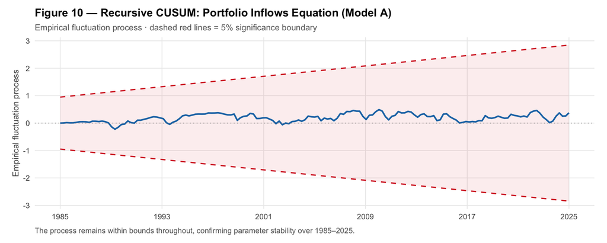

```r
cusum_A <- efp(residuals(var_A)[, "d_ln_pip"] ~ 1, type = "Rec-CUSUM")

# Extract process and boundaries
n       <- length(cusum_A$process)
time_ix <- seq(0, 1, length.out = n)
bound   <- boundary(cusum_A, alpha = 0.05)

cusum_df <- tibble(
  t       = time_ix,
  process = as.numeric(cusum_A$process),
  upper   = as.numeric(bound),
  lower   = -as.numeric(bound)
)

ggplot(cusum_df, aes(x = t)) +
  geom_ribbon(aes(ymin = lower, ymax = upper),
              fill = "#d62728", alpha = 0.08) +
  geom_line(aes(y = upper), color = "#d62728",
            linewidth = 0.7, linetype = "dashed") +
  geom_line(aes(y = lower), color = "#d62728",
            linewidth = 0.7, linetype = "dashed") +
  geom_line(aes(y = process), color = "#1f77b4",
            linewidth = 0.9) +
  geom_hline(yintercept = 0, color = "grey50",
             linewidth = 0.4, linetype = "dotted") +
  scale_x_continuous(
    breaks = seq(0, 1, by = 0.2),
    labels = function(x) {
      yr <- 1985 + round(x * (2025 - 1985))
      as.character(yr)
    }
  ) +
  labs(
    title    = "Figure 10 — Recursive CUSUM: Portfolio Inflows Equation (Model A)",
    subtitle = "Empirical fluctuation process · dashed red lines = 5% significance boundary",
    caption  = "The process remains within bounds throughout, confirming parameter stability over 1985–2025.",
    x        = NULL,
    y        = "Empirical fluctuation process"
  ) +
  theme_chf() +
  theme(
    plot.caption = element_text(size = 9, color = "grey40",
                                hjust = 0, margin = margin(t = 8))
  )
```

## 12.5 Residual Plots — Model A

This subsection isn’t a formal test like the previous ones but rather a visual sanity check. Plotting the residuals of each equation over time gives a glance of whether there are obvious outliers, remaining trends, or volatility clustering that the tests above might have not fully captured.

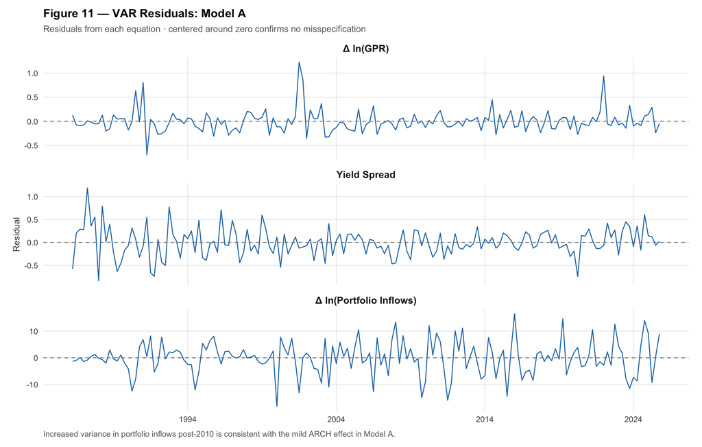

```r
as.data.frame(residuals(var_A)) %>%
  mutate(date = df %>%
           filter(date >= as.Date("1985-01-01"),
                  !is.na(d_ln_gpr), !is.na(d_ln_pip), !is.na(spread)) %>%
           pull(date) %>%
           tail(nrow(residuals(var_A)))) %>%
  pivot_longer(-date, names_to = "eq", values_to = "resid") %>%
  mutate(eq = recode(eq,
    d_ln_gpr = "Δ ln(GPR)",
    spread   = "Yield Spread",
    d_ln_pip = "Δ ln(Portfolio Inflows)"
  ),
  eq = factor(eq, levels = c("Δ ln(GPR)",
                              "Yield Spread",
                              "Δ ln(Portfolio Inflows)"))) %>%
  ggplot(aes(x = date, y = resid)) +
  geom_line(color = "#1f77b4", linewidth = 0.5) +
  geom_hline(yintercept = 0, linetype = "dashed",
             color = "grey50", linewidth = 0.4) +
  facet_wrap(~eq, scales = "free_y", ncol = 1) +
  scale_x_date(date_breaks = "10 years", date_labels = "%Y") +
  labs(
    title    = "Figure 11 — VAR Residuals: Model A",
    subtitle = "Residuals from each equation · centered around zero confirms no misspecification",
    caption  = "Increased variance in portfolio inflows post-2010 is consistent with the mild ARCH effect in Model A.",
    x        = NULL,
    y        = "Residual"
  ) +
  theme_chf() +
  theme(
    strip.text   = element_text(face = "bold", size = 11),
    plot.caption = element_text(size = 9, color = "grey40",
                                hjust = 0, margin = margin(t = 8))
  )
```

# 13 Historical Decomposition

The historical decomposition isolates the contribution of GPR shocks to portfolio inflow fluctuations at each point in time. Blue bars indicate quarters in which GPR shocks increased inflows (safe-haven effect active), while red bars indicate negative contributions. Unlike the VAR coefficients, which capture the average relationship between GPR and inflows across the full sample, the historical decomposition traces the realised structural shocks quarter by quarter. It therefore shows how much of each inflow movement can be attributed specifically to geopolitical risk shocks rather than to yield spread dynamics or the inflows’ own autoregressive behavior.

```r
# Historical Decomposition via Moving Average Representation:

# Isolates the contribution of a single structural shock (GPR) to a target
# variable (portfolio inflows) at each point in time
# Uses the Cholesky matrix from Section 9.5 for identification consistency

compute_historical_decomposition <- function(var_model,
                                             target_variable,
                                             shock_variable,
                                             cholesky_mat = NULL) {

  # Use pre-computed Cholesky from Section 9.5 if provided
  if (is.null(cholesky_mat)) {
    cholesky_mat <- t(chol(summary(var_model)$covres))
  }

  n_vars             <- var_model$K
  n_lags             <- var_model$p
  resid_matrix       <- residuals(var_model)
  n_obs              <- nrow(resid_matrix)

  # Convert reduced-form residuals to orthogonal structural shocks
  # via u_t = P^{-1} * e_t where P is the Cholesky matrix
  structural_shock_matrix <- t(solve(cholesky_mat) %*% t(resid_matrix))

  # Identify which column corresponds to target variable and shock variable
  target_col <- which(colnames(resid_matrix) == target_variable)
  shock_col  <- which(colnames(resid_matrix) == shock_variable)

  # Build companion matrix:
  # Stacks all VAR lags into a single first-order system
  # Required to compute MA coefficient matrices via matrix powers
  companion_dim    <- n_vars * n_lags
  companion_mat    <- matrix(0, companion_dim, companion_dim)
  companion_mat[1:n_vars, ] <- Bcoef(var_model)[, 1:companion_dim]

  if (n_lags > 1)
    companion_mat[(n_vars + 1):companion_dim,
                  1:(n_vars * (n_lags - 1))] <- diag(n_vars * (n_lags - 1))

  # Compute MA coefficient matrices Φ(h) for h = 0, ..., T:
  # Φ(h) = top-left n_vars × n_vars block of companion matrix raised to power h
  # Φ(0) = identity matrix (no dynamics at horizon zero)
  ma_coef_array         <- array(0, c(n_vars, n_vars, n_obs + 1))
  ma_coef_array[,,1]    <- diag(n_vars)
  companion_mat_power   <- diag(companion_dim)

  for (horizon in seq_len(n_obs)) {
    companion_mat_power        <- companion_mat_power %*% companion_mat
    ma_coef_array[,,horizon+1] <- companion_mat_power[1:n_vars, 1:n_vars]
  }

  # IRF vector: response of target to shock at each horizon
  irf_at_each_horizon <- sapply(0:n_obs, function(h)
    as.numeric(ma_coef_array[target_col,,h+1] %*% cholesky_mat[, shock_col])
  )

  # Structural shock series for the GPR variable
  gpr_shock_realisation <- structural_shock_matrix[, shock_col]

  # Convolution: historical contribution at each quarter:
  # contribution[t] = sum_{s=1}^{t} IRF[t-s] * shock[s]
  # Accumulates the effect of all past GPR shocks weighted by their IRF path
  quarterly_gpr_contribution <- numeric(n_obs)

  for (quarter in seq_len(n_obs)) {
    irf_weights                        <- (quarter - 1):0
    quarterly_gpr_contribution[quarter] <- sum(
      irf_at_each_horizon[irf_weights + 1] *
      gpr_shock_realisation[seq_len(quarter)]
    )
  }

  quarterly_gpr_contribution
}

# Apply decomposition to Model A:
# Pass cholesky_lower_A from Section 9.5 to ensure identification consistency
gpr_inflow_contributions <- compute_historical_decomposition(
  var_model       = var_A,
  target_variable = "d_ln_pip",
  shock_variable  = "d_ln_gpr",
  cholesky_mat    = cholesky_lower_A
)

# Align contribution series with quarterly dates
model_a_hd_dates <- df %>%
  filter(date >= as.Date("1985-01-01")) %>%
  dplyr::select(date, d_ln_gpr, spread, d_ln_pip) %>%
  na.omit() %>%
  tail(length(gpr_inflow_contributions)) %>%
  pull(date)

# Build plotting dataframe
historical_decomp_df <- tibble(
  quarter_date          = model_a_hd_dates,
  gpr_contribution      = gpr_inflow_contributions,
  gpr_contribution_cum  = cumsum(gpr_inflow_contributions),
  safe_haven_active     = gpr_inflow_contributions > 0
)
```

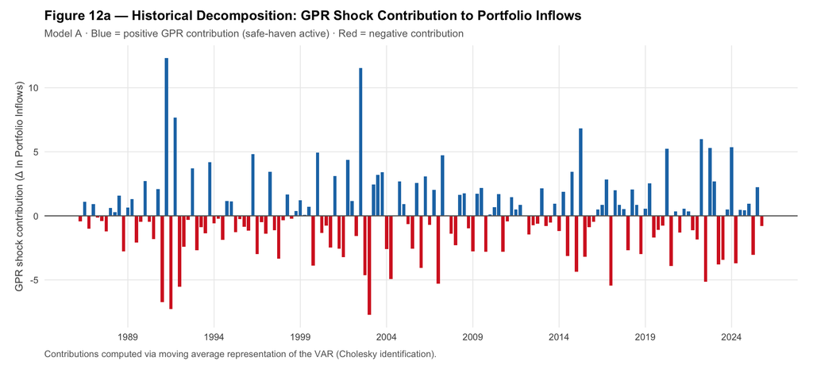

```r
ggplot(historical_decomp_df,
       aes(x = quarter_date, y = gpr_contribution,
           fill = safe_haven_active)) +
  geom_col(width = 70, show.legend = FALSE) +
  scale_fill_manual(values = c("TRUE"  = "#1f77b4",
                               "FALSE" = "#d62728")) +
  geom_hline(yintercept = 0, color = "grey40", linewidth = 0.5) +
  scale_x_date(date_breaks = "5 years", date_labels = "%Y") +
  labs(
    title    = "Figure 12a — Historical Decomposition: GPR Shock Contribution to Portfolio Inflows",
    subtitle = "Model A · Blue = positive GPR contribution (safe-haven active) · Red = negative contribution",
    caption  = "Contributions computed via moving average representation of the VAR (Cholesky identification).",
    x        = NULL,
    y        = "GPR shock contribution (Δ ln Portfolio Inflows)"
  ) +
  theme_chf() +
  theme(
    plot.caption = element_text(size = 9, color = "grey40",
                                hjust = 0, margin = margin(t = 8))
  )
```